# Chapter 1 — The bottom line, and how to read the rest

Problem A is the single-hand blackjack decision (hit / stand / double / split / surrender), and it has an *exact* answer: basic strategy, a lookup table proven optimal. That makes it a rare thing — a reinforcement-learning problem where we already know the right answer for every state. So we can use it as a **ruler**: train a neural agent, and measure precisely where and how it departs from the truth.

This chapter puts the result up front, then hands you the two tools you need for everything after: the **two metrics** (and why they disagree), and the **decision-tree frame** (the lens that, by Chapter 7, explains every finding).

### The chapters

1. **The bottom line, and how to read the rest** — the scoreboard, the agreement-vs-edge lens, the decision-tree frame. *(this chapter)*
2. **The diagnosis: the wild double** — the oscillating value on the terminal double, its two mechanisms, the Q-grid.
3. **Cornering the cause** — every fixable explanation (capacity, coverage, settling, learning-order, reward variance, the standard knobs) tested and ruled out — each leaving a usable method behind.
4. **The real cause: representation** — where the errors live (the low-margin seam = the function-approximation floor), and encoding as a sharpness dial.
5. **Honesty and dynamics** — how we kept ourselves honest, and what more training actually buys (a plateau, not a climb — the peak you see is a transient).
6. **Completing the game** — adding split, then surrender, and what the full action set changes.
7. **What this actually was** — the synthesis: every finding from three axes, and why "the table wins" is the measured cost of model-free generality, not a defeat.

```python
import sys; sys.path.insert(0, '.')
import statistics as st
import pandas as pd
from runs import load_runs, learning_curve, cell_categories, agreement_on, sample_counts, diff_cells, show, provenance, describe, OPTIMUM_PCT, EDGE_SE_PCT

df = load_runs(); dqn = df[df.method == 'dqn']

def back_half(path):
    a = [cp['agreement'] for cp in learning_curve(path) if cp.get('agreement') is not None]
    return st.mean(a[len(a) // 2:]) if a else float('nan')

# the network's canonical 240-cell grid (any no-split DQN run) — the common ground for scoring
net_grid = set(cell_categories(dqn[~dqn.with_splits].iloc[0].path))
# tabular Q-learner (no-split, 5M) scored on that same grid; naive DQN; the best DQN we reached
tab = df[(df.method == 'tabular') & (df.episodes == 5_000_000) & (~df.with_splits)]
naive = dqn[(dqn.hidden == '[64, 64]') & (dqn.episodes == 1_000_000) & (~dqn.swa) & (dqn.lr_schedule == 'constant')
            & (dqn.reward_baseline == 'none') & (dqn.double_after == 0) & (~dqn.with_splits)]
naive = naive[naive.edge_pct < 4.0]                       # drop one divergent-edge run (Ch.5)
best = dqn[(~dqn.with_splits) & dqn.has_model].assign(bh=lambda d: [back_half(p) for p in d.path]) \
          .sort_values('bh').iloc[-1]

# The reference these no-split agents could reach is the NO-SPLIT basic strategy. The per-run basic_edge_pct
# is ONE eval_seed=0, 200k-hand sample (SE ~0.26%/hand) that drew low (~0.09%), so it is NOT the optimum.
# The true 6-deck S17 3:2 basic edge is ~0.54% with the full action set (measured in-harness at 0.58%±0.10
# over 1.4M hands), and ~1.11% with no split/surrender — the proper reference for these no-split agents
# (see runs.OPTIMUM_PCT). Basic plays the FULL set; the no-split agents cannot, so 1.11% is their ceiling.
basic_edge = OPTIMUM_PCT['trimmed']

scoreboard = pd.DataFrame([
    {'method': 'tabular Q-learner', 'agreement': st.mean([agreement_on(p, net_grid) for p in tab.path]), 'edge': tab.edge_pct.mean(), 'tuning': 'none'},
    {'method': 'naive DQN',         'agreement': naive.agreement.mean(),                                  'edge': naive.edge_pct.mean(), 'tuning': 'defaults'},
    {'method': 'best DQN',          'agreement': back_half(best.path),                                    'edge': best.edge_pct,        'tuning': 'full stack'},
    {'method': 'basic strategy (no-split optimum)', 'agreement': float('nan'),                            'edge': basic_edge,           'tuning': '—'},
])
show(scoreboard, pct=['agreement'], num=['edge'],
     caption='Problem A scoreboard — agreement = match to the table on the common 240-cell grid (exact, '
             'noiseless); edge = % of stake lost per hand, lower better. The optimum row is the NO-SPLIT basic '
             'strategy (~1.11%), the ceiling these no-split agents could reach; every learner edge is one 200k '
             'seed-0 eval (±0.26%/hand), so edge gaps under ~0.5% are within noise and should not be ranked.',
     source=('source — agreement is exact; edges are single seed-0 200k evals (±0.26%/hand):<br>'
             '&nbsp;&nbsp;tabular Q-learner — ' + provenance(tab).replace('source: ', '') + '<br>'
             '&nbsp;&nbsp;naive DQN — ' + provenance(naive).replace('source: ', '') + '<br>'
             '&nbsp;&nbsp;best DQN — ' + provenance(best).replace('source: ', '') + ' · scored on its back-half<br>'
             '&nbsp;&nbsp;no-split optimum — basic strategy, no split/surrender: literature ≈1.11%; in-harness full basic 0.58%±0.10 over 1.4M hands'))
```

Problem A scoreboard — agreement = match to the table on the common 240-cell grid (exact, noiseless); edge = % of stake lost per hand, lower better. The optimum row is the NO-SPLIT basic strategy (~1.11%), the ceiling these no-split agents could reach; every learner edge is one 200k seed-0 eval (±0.26%/hand), so edge gaps under ~0.5% are within noise and should not be ranked.

| method | agreement | edge | tuning |
| --- | --- | --- | --- |
| tabular Q-learner | 92.8% | 1.34 | none |
| naive DQN | 82.1% | 1.94 | defaults |
| best DQN | 91.1% | 0.90 | full stack |
| basic strategy (no-split optimum) | nan% | 1.11 | — |

source — agreement is exact; edges are single seed-0 200k evals (±0.26%/hand):  
tabular Q-learner — mean over 6 runs — tabular Q-learner · 1/n step · 5M ep · seeds 42  
naive DQN — mean over 17 runs — DQN · [64, 64] · constant lr ? · 1M ep · seeds 42, 43, 44 · (varies: encoding, double_dqn)  
best DQN — single run — DQN · onehot · [64, 64] · harmonic lr 0.001→1e-05 · 5M ep · stand-baseline · double@500k · Double-DQN · seed 42 · scored on its back-half  
no-split optimum — basic strategy, no split/surrender: literature ≈1.11%; in-harness full basic 0.58%±0.10 over 1.4M hands

## 1.1 The headline

Two readings of the same three rows:

- On **agreement** (does the policy match the table cell-by-cell), the tabular learner leads (~0.93) and the best network trails by a couple of points (~0.91) — and it took the *full stack* of fixes to get there, against the table's *zero* tuning.
- On **edge** (money actually lost per hand), the best network and the table are **within noise of each other** (~0.9% vs ~1.3%, a gap inside the ±0.26%/hand eval band) — neither "wins" on edge at this precision. The proper reference for these no-split agents is the **no-split basic strategy, ~1.11%**, and both learners sit within noise of it. (Each edge here is one 200k seed-0 sample and they share that draw, so read the absolute numbers with the band, not as exact.)

Every edge number is **one** measurement — the fresh-shoe engine, 200k hands at a single seed — so it carries a ±0.26%/hand standard error; agreement, by contrast, is computed from the deterministic policy and is **exact**. The only structural asymmetry is the action set — basic may split, the no-split agents may not — which is itself part of the story (it is why their ceiling is ~1.11%, not the full game's ~0.54%).

So the honest verdict is **not** "the net failed." It's: *the table wins on exactness, simplicity, and zero tuning — not on capability.* On edge the net is within noise of the table and of its own optimum; hold onto the fact that "table wins on exactness" and "net is competent" are both true, because Chapter 7 pays it off.

One more thing the scoreboard hides: the two methods don't even evaluate the *same cells natively*. The network has a learned answer at **every** canonical cell (it generalizes); the table only has the cells it actually **visited**. We score both on their shared grid here, but that mismatch isn't a nuisance to paper over — it *is* a finding (generalization vs coverage), and it returns in Chapter 7.

## 1.2 The two-metric lens (agreement vs edge)

Those two columns disagree on purpose, and keeping them apart is the single most useful habit for reading everything that follows. Define them once:

- **Agreement** — fraction of the 240 cells where the agent's action equals basic strategy's. Every cell counts **equally**, common or rare. Computed from the deterministic policy, so it is **exact**.
- **Edge** — the house edge measured by playing many hands. Each mistake is weighted by **how often that cell occurs and how much it costs** — and, measured over 200k hands, it carries a ±0.26%/hand band.

They diverge whenever the agent's mistakes are concentrated in cells that are *less frequent* or *cheap* — then agreement drops but edge barely moves. That's exactly what the scoreboard shows (the net trails on agreement while its edge stays within noise of the table's), and the cell below makes it concrete: the net's disagreement cells are visited only about *half as often* as the cells it gets right, so they carry less weight in money terms.

A *third* number is tempting and misleading: the agent's **self-gap** — how much better it *thinks* its chosen action is than the alternative. Smaller self-gaps look like "more confident, so better," but they don't track edge at all (Chapter 5 shows a run that shrank its self-gap while its edge stood still). Trust agreement and edge; treat the self-gap as the agent grading its own homework.

```python
# why its few errors barely move edge: its wrong cells are the lower-frequency ones
sc = sample_counts(best.path)
def freq(c): return sum(sc.get((c['player_value'], c['is_soft'], c['dealer_upcard'], a), 0) for a in ('hit', 'stand', 'double'))
cells = diff_cells(best.path)
dis = [c for c in cells if c['category'] == 'genuine_disagreement']
agr = [c for c in cells if c['category'] == 'agree']
freqcmp = pd.DataFrame([
    {'cell group': 'cells it gets RIGHT', 'count': len(agr), 'mean training visits': st.mean(freq(c) for c in agr)},
    {'cell group': 'cells it gets WRONG', 'count': len(dis), 'mean training visits': st.mean(freq(c) for c in dis)},
])
show(freqcmp, num=['mean training visits'],
     caption='Best DQN: its disagreements sit in the lower-frequency cells — lighter in edge, full weight in agreement.',
     source=provenance(best, role='best DQN'))
```

Best DQN: its disagreements sit in the lower-frequency cells — lighter in edge, full weight in agreement.

| cell group | count | mean training visits |
| --- | --- | --- |
| cells it gets RIGHT | 223 | 26729.57 |
| cells it gets WRONG | 15 | 14445.00 |

source: best DQN · single run — DQN · onehot · [64, 64] · harmonic lr 0.001→1e-05 · 5M ep · stand-baseline · double@500k · Double-DQN · seed 42

## 1.3 The decision-tree frame (the spine)

Here is the lens for the whole document. **Basic strategy is a decision tree** — and your own one-page rule list ("hard 17+ → stand; 11 → double; split aces and eights…") *is* that tree written out: a stack of threshold rules, one action per region. A neural network is a *different kind* of partition of the same space. The two differ along **three axes**, and every finding in this project is one of these axes showing up:

| axis | the table (decision tree) | the network |
| --- | --- | --- |
| **boundary** | a **hard** wall — you're on one side or the other | a **soft** ramp — it interpolates across |
| **cut direction** | **axis-aligned** — splits on one feature ("total ≥ 17") | **oblique** — splits on a weighted mix of features |
| **cells** | **independent** — each leaf is its own number | **shared** — adjacent cells share weights |

These three words — **hard/soft, axis-aligned/oblique, independent/shared** — are load-bearing. Read ahead with them in hand:

- the **over-doubling** at boundaries (Ch. 2, 4) is *soft cuts where the tree has walls*;
- the **oscillation** of the double (Ch. 2) is *shared/coupled values where the tree has independent leaves*;
- the **encoding mattering** (Ch. 4) is *the smoothness prior fighting a hard, axis-aligned boundary*;
- the **capacity not mattering** (Ch. 3) is *the boundaries being representable all along*.

We introduce this as a *frame*, not a conclusion. Chapters 2–6 are the evidence; Chapter 7 returns here and re-derives the entire project from these three axes — and from one last reframe: on a problem whose model is *known*, computing the table is the right answer, and the network's gap is the measurable **cost of pretending you don't know the model**. That's what this whole investigation actually measures.

# Chapter 2 — The diagnosis: the wild double

Chapter 1 left a gap: a naive network plateaus well short of the table, and no single knob moves it. The most *visible* pathology in those runs is a value that never settles — the **terminal `double` action**, whose estimate swings ±1–2 for the entire run. The final policy is therefore a snapshot of a value still in motion.

This chapter pins that down. It shows the oscillation is real and not a fluke of one cell — we *map* it across the whole board — rules out the obvious cause (under-sampling), and separates the two mechanisms that could produce it. Read it as a symptom characterized precisely: Chapter 3 chases the fix and finds, tellingly, that curing the oscillation *barely moves agreement*. Naming this suspect exactly is what lets Chapter 3 rule it out.

```python
import sys; sys.path.insert(0, '.')
import statistics as st
import numpy as np
import pandas as pd
import matplotlib.pyplot as plt
from runs import load_runs, probe_trajectory, sample_counts, learning_curve, show, provenance, describe, fignote

df = load_runs(); dqn = df[df.method == 'dqn']
# the canonical NAIVE run: onehot, constant lr, no baseline/curriculum/soft-target — the wild-double
# regime — logged with a fine-grained q-grid (2M episodes, 2000 checkpoints) so the oscillation resolves.
# (There is no 5M constant-lr run *by design*: past ~2M we always decay the step, Ch3, which removes the
# oscillation — so this is the longest, finest look at the pathology actually happening.)
naive = dqn[(dqn.encoding=='onehot') & (dqn.lr_schedule=='constant') & dqn.has_qgrid
            & (dqn.episodes==2_000_000) & (dqn.reward_baseline=='none') & (dqn.double_after==0)
            & (dqn.target_tau==0.0) & (~dqn.swa)].iloc[0]
# a matched soft/EMA-target run (the Mechanism-1 probe)
soft = dqn[(dqn.target_tau>0) & dqn.has_qgrid].iloc[0]
print('naive run agreement: %.3f' % naive.agreement, ' |', provenance(naive, role='naive exemplar'))
print('mechanism probe     :', provenance(soft, role='soft-target, otherwise matched'))
```

```
naive run agreement: 0.838  | source: naive exemplar · single run — DQN · onehot · [64, 64] · constant lr 0.001 · 2M ep · seed 42
mechanism probe     : source: soft-target, otherwise matched · single run — DQN · onehot · [64, 64] · constant lr 0.001 · 2M ep · soft-target · seed 42
```

## 2.1 The symptom: `Q(double)` never settles

Watch one probe cell over training — *soft-20 vs dealer-8*. `Q(stand)` is steady; `Q(double)` swings the whole run. Doubling here is **terminal** (one card, the hand resolves) and high-variance (a ±2 stake on a near-coin-flip), so its running estimate never converges. The final action on this cell is just where the swing happened to sit at the last checkpoint.

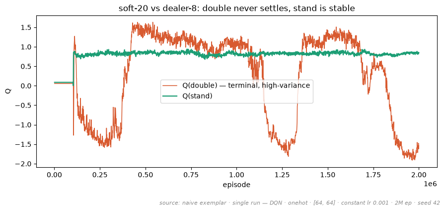

```
back-half std   Q(double)=1.14   vs   Q(stand)=0.03
```

```python
ep, q_dbl = probe_trajectory(naive.path, 'soft20_v8', 'double')
_,  q_std = probe_trajectory(naive.path, 'soft20_v8', 'stand')
fig, ax = plt.subplots(figsize=(9, 4))
ax.plot(ep, q_dbl, color='#D85A30', lw=1.1, label='Q(double) — terminal, high-variance')
ax.plot(ep, q_std, color='#1D9E75', lw=1.6, label='Q(stand)')
ax.set_xlabel('episode'); ax.set_ylabel('Q'); ax.set_title('soft-20 vs dealer-8: double never settles, stand is stable')
ax.legend(); plt.tight_layout(); fignote(provenance(naive, role='naive exemplar')); plt.show()
print('back-half std   Q(double)=%.2f   vs   Q(stand)=%.2f'
      % (st.pstdev(q_dbl[len(q_dbl)//2:]), st.pstdev(q_std[len(q_std)//2:])))
```

## 2.2 The wild double, mapped

*(Run note: this is the 2M constant-lr run with 2000 logged checkpoints — the longest, finest-grained look at the oscillation. There is no 5M constant-lr counterpart by design: past ~2M we always decay the step (Chapter 3), which removes the wildness, so a longer run would have nothing left to show here.)*

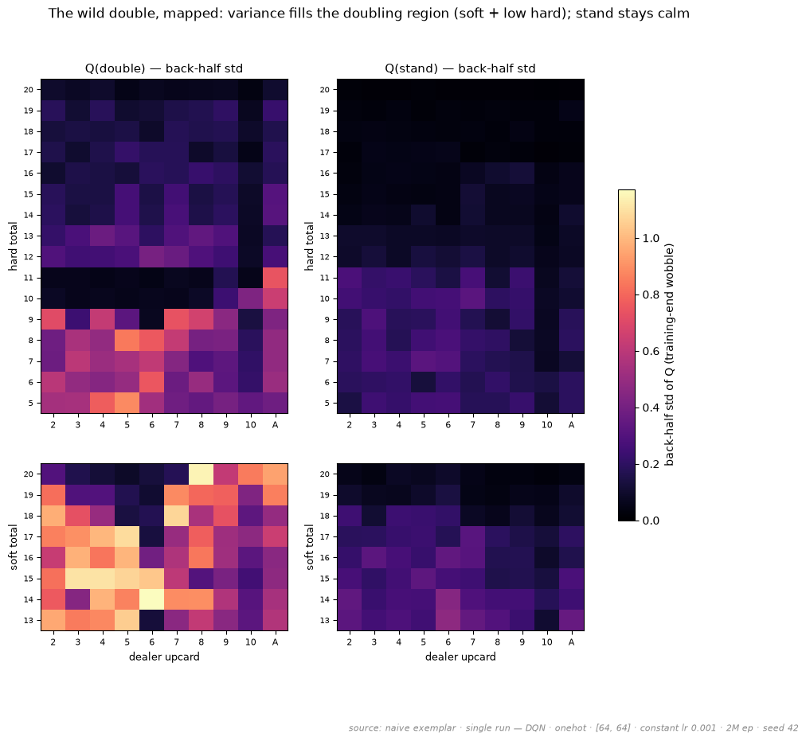

```
mean back-half std   Q(double)=0.39   Q(stand)=0.14   | wildest double cell: soft14_v6
```

```python
def grid_std(path, action):
    cps = [cp['q_grid'] for cp in learning_curve(path) if cp.get('q_grid')]
    half = cps[len(cps)//2:]
    return {c: float(np.std([g[c][action] for g in half])) for c in cps[-1]}

UP = list(range(2, 12))
HARD = list(range(20, 4, -1))      # 20..5
SOFT = list(range(20, 12, -1))     # 20..13
def matrix(std, kind, totals):
    M = np.full((len(totals), len(UP)), np.nan)
    for i, t in enumerate(totals):
        for j, u in enumerate(UP):
            key = '%s%d_v%d' % (kind, t, u)
            if key in std: M[i, j] = std[key]
    return M

sd, ss = grid_std(naive.path, 'double'), grid_std(naive.path, 'stand')
vmax = max(max(sd.values()), 0.8)
fig, axes = plt.subplots(2, 2, figsize=(11, 9), gridspec_kw={'height_ratios': [16, 8]})
xlab = [str(u) if u < 11 else 'A' for u in UP]
for col, (std, name) in enumerate([(sd, 'Q(double)'), (ss, 'Q(stand)')]):
    for row, (kind, totals) in enumerate([('hard', HARD), ('soft', SOFT)]):
        ax = axes[row][col]
        im = ax.imshow(matrix(std, kind, totals), aspect='auto', cmap='magma', vmin=0, vmax=vmax)
        ax.set_xticks(range(len(UP))); ax.set_xticklabels(xlab, fontsize=8)
        ax.set_yticks(range(len(totals))); ax.set_yticklabels(totals, fontsize=7)
        ax.set_ylabel(kind + ' total', fontsize=9)
        if row == 0: ax.set_title(name + ' — back-half std', fontsize=11)
        if row == 1: ax.set_xlabel('dealer upcard', fontsize=9)
fig.suptitle('The wild double, mapped: variance fills the doubling region (soft + low hard); stand stays calm', fontsize=12)
fig.colorbar(im, ax=axes, shrink=0.6, label='back-half std of Q (training-end wobble)')
fignote(provenance(naive, role='naive exemplar')); plt.show()
print('mean back-half std   Q(double)=%.2f   Q(stand)=%.2f   | wildest double cell: %s'
      % (np.mean(list(sd.values())), np.mean(list(ss.values())), max(sd, key=sd.get)))
```

## 2.2b Is this run representative?

Every figure in this chapter is a **single run** — seed 42, the one logged at 2000-checkpoint resolution. So is its oscillation typical? The *phenomenon* is: every constant-lr run oscillates, and decaying the step clearly calms it. But this exemplar sits near the **top** of the spread — we use it because it is the most finely logged. The table below marks where it sits, so the amplitude on screen reads in context: the qualitative pattern (which cells swing) is general; the height is high-end.

```python
osc = dqn[(~dqn.with_splits) & dqn.soft20_double_std.notna()].copy()
osc['lr'] = osc.lr_schedule.map(lambda s: 'constant (naive)' if s == 'constant' else 'decaying')
summary = (osc.groupby('lr').soft20_double_std
              .agg(n='count', median='median', mean='mean', min='min', max='max').reset_index())
show(summary, num=['median', 'mean', 'min', 'max'],
     caption='Oscillation (back-half std of Q(double) on soft-20 v8) across ALL no-split DQN runs — '
             'the pathology is general; decay calms it (previews Ch3).',
     source='source: every no-split DQN run with this probe logged (%d runs: %d constant, %d decaying)'
            % (len(osc), (osc.lr=='constant (naive)').sum(), (osc.lr=='decaying').sum()))
print("this chapter's exemplar sits at %.2f — near the top of the constant-lr spread (median %.2f)"
      % (naive.soft20_double_std, osc[osc.lr == 'constant (naive)'].soft20_double_std.median()))
```

Oscillation (back-half std of Q(double) on soft-20 v8) across ALL no-split DQN runs — the pathology is general; decay calms it (previews Ch3).

| lr | n | median | mean | min | max |
| --- | --- | --- | --- | --- | --- |
| constant (naive) | 41 | 0.52 | 0.59 | 0.15 | 1.34 |
| decaying | 24 | 0.19 | 0.31 | 0.06 | 1.01 |

source: every no-split DQN run with this probe logged (65 runs: 41 constant, 24 decaying)

```
this chapter's exemplar sits at 1.14 — near the top of the constant-lr spread (median 0.52)
```

## 2.3 Not data quantity — and two failures, not one

The natural next guess is that the swinging cells are starved of data. The counts complicate that story, usefully. Put each cell's oscillation amplitude (back-half std of `Q(double)`) next to its visit counts:

```python
sc = sample_counts(naive.path)
cps = [cp['q_grid'] for cp in learning_curve(naive.path) if cp.get('q_grid')]
half = cps[len(cps)//2:]
import numpy as np
def row(label, key, correct, v, sf, u):
    return {'cell': label,
            'double': sc.get((v,sf,u,'double'),0), 'stand': sc.get((v,sf,u,'stand'),0), 'hit': sc.get((v,sf,u,'hit'),0),
            'std Q(dbl)': float(np.std([g[key]['double'] for g in half])),
            'correct': correct, 'agent plays': max(cps[-1][key], key=cps[-1][key].get)}
rows = [row('soft-20 v8  (oscillates)',     'soft20_v8', 'stand',  20, True,  8),
        row('soft-20 v6  (over-doubles)',   'soft20_v6', 'stand',  20, True,  6),
        row('hard-11 v6  (correct double)', 'hard11_v6', 'double', 11, False, 6)]
show(pd.DataFrame(rows), num=['std Q(dbl)'],
     caption='Two failures side by side: soft-20 v8 oscillates (high std) on the FEWEST samples yet lands right; '
             'soft-20 v6 over-doubles STABLY (low std) on more samples. Neither is fixed by data quantity.',
     source=provenance(naive, role='naive exemplar'))
```

Two failures side by side: soft-20 v8 oscillates (high std) on the FEWEST samples yet lands right; soft-20 v6 over-doubles STABLY (low std) on more samples. Neither is fixed by data quantity.

| cell | double | stand | hit | std Q(dbl) | correct | agent plays |
| --- | --- | --- | --- | --- | --- | --- |
| soft-20 v8 (oscillates) | 822 | 1948 | 193 | 1.14 | stand | stand |
| soft-20 v6 (over-doubles) | 1604 | 446 | 141 | 0.13 | stand | double |
| hard-11 v6 (correct double) | 6186 | 679 | 1075 | 0.05 | double | double |

source: naive exemplar · single run — DQN · onehot · [64, 64] · constant lr 0.001 · 2M ep · seed 42

## 2.3b What the table actually shows

Two distinct failures sit side by side. *soft-20 v8* genuinely **oscillates** (std 1.14) on the *fewest* samples — yet it still lands on the correct action. *soft-20 v6* does the opposite: it **over-doubles stably** (std 0.13) on *more* samples and stays wrong — a bias, not a wobble. The original "oscillating *or* wrong" framing quietly merged a *variance* failure with a *bias* failure; they are different things.

On under-sampling specifically: across all 240 cells the oscillation amplitude is only weakly tied to sample count (r ≈ -0.31) — the least-sampled marginal cells do swing most. But the swing is not *caused* by the count. These cells have hundreds-to-thousands of visits, and the decisive test is Chapter 3: a decaying step settles the same cell on the *same data budget*. If quantity were the lever, fixing the budget and changing only the step couldn't help — it does. Count merely tracks which cells are marginal; the step schedule decides whether they converge. The stable over-double, meanwhile, is a *representation* limit — Chapter 4. This table is where those two threads first separate.

## 2.4 Two mechanisms, told apart by experiment

Two things could keep the value moving:

- **Mechanism 1 — feedback loop:** the estimate picks the action, which picks the data, which feeds back into the estimate. Anything that stabilizes the bootstrap or the data would damp it.
- **Mechanism 2 — constant-gain variance:** a running mean of a high-variance reward under a *constant* learning rate has non-vanishing steady-state variance. It converges to a *distribution*, not a point.

A soft / EMA target network damps Mechanism 1. If the double were a feedback-loop problem, it would settle. It doesn't — because `double` is **terminal**: its target is the raw ±2 reward, so the target network was never in its path. The soft target shrinks the swing but leaves it wild (well above a calm `Q(stand)`), isolating Mechanism 2. (Exploring starts, which force uniform data, likewise fail to settle it — same conclusion, Chapter 3.)

```python
def bh(path, cell, act):
    _, v = probe_trajectory(path, cell, act); return st.pstdev(v[len(v)//2:])
comp = pd.DataFrame([
    {'setting': 'constant lr',             'action': 'double', 'back-half std': bh(naive.path, 'soft20_v8', 'double')},
    {'setting': 'soft / EMA target',       'action': 'double', 'back-half std': bh(soft.path,  'soft20_v8', 'double')},
    {'setting': 'constant lr (for scale)', 'action': 'stand',  'back-half std': bh(naive.path, 'soft20_v8', 'stand')},
])
show(comp, num=['back-half std'],
     caption='soft-20 v8: a soft target shrinks the swing but does not settle it (vs a calm stand) → not the feedback loop',
     source='source: two matched single runs — ' + describe(naive) + ' (the second run is identical, plus a soft-target)')
```

soft-20 v8: a soft target shrinks the swing but does not settle it (vs a calm stand) → not the feedback loop

| setting | action | back-half std |
| --- | --- | --- |
| constant lr | double | 1.14 |
| soft / EMA target | double | 0.65 |
| constant lr (for scale) | stand | 0.03 |

source: two matched single runs — DQN · onehot · [64, 64] · constant lr 0.001 · 2M ep · seed 42 (the second run is identical, plus a soft-target)

## 2.5 Conclusion

The naive runs carry an oscillating value on the terminal `double`: a high-variance reward learned with a constant-gain step, so the estimate never converges — and it is a *structural* band across the live-doubling region, not one unlucky cell. Its data *budget* is not the lever — more samples do not settle it (Chapter 3 does, on the same budget) — and it is **not** the feedback loop. The tabular learner avoided it for free: its `1/n` step shrinks over time, so its averages converge; the network's constant Adam step does not.

The obvious fix is to make the step decay — Chapter 3. But hold the verdict loosely: there, settling the double (pushing the step low) barely moves agreement — if anything it costs a little (the tightest-settling run lands at 0.81, just under the oscillating baseline's 0.83), while the runs that score higher get there by reaching (a higher step that leaves the double noisy, 0.89), not by settling. A variance we can see and fix turns out not to be the binding constraint. The thing that actually caps agreement is waiting in Chapters 3–4.

# Chapter 3 — Cornering the cause

Chapter 2 named the wild double and showed it is a *symptom*. This chapter is the elimination round. Every **fixable** explanation for the agreement gap gets the same treatment — settling, learning-order, capacity, coverage, reward variance, and the standard knobs — and each is ruled out as *the* cause. The shape is deliberately repetitive: **hypothesis → test → verdict → keeper**. None of these experiments is wasted: each leaves a *usable method* or a *clean fact* behind even when it fails to close the gap. The cumulative force of one independent null after another is what finally pins the cause on representation (Chapter 4).

What counts as a "keeper" is decided by data, not story. Three leave a usable method — a stable schedule (3.1), a curriculum (3.2), and a network sized to the rules (3.3) — though, read honestly, their value is stability and parsimony, not a clear gain on the agreement metric: none of the three closes the cap, and each verdict says so. The other three leave only a clean fact (3.4 coverage, 3.5 reward variance, 3.6 the knobs) — interesting nulls, each ruling a suspect out. Every table below carries its source, and where an effect is confounded we say so rather than claim it.

## 3.1 Settling — the learning-rate schedule

The wild double is constant-gain variance (Ch2), so the textbook fix is to **decay the step**. It works — the double settles — but a *single global* step size faces a **reach-vs-settle frontier**: low enough to settle the terminal double, high enough to learn the rest of the map, and it cannot be both at once. Three runs trace it.

```python
import sys; sys.path.insert(0, '.')
import statistics as st
import pandas as pd
import matplotlib.pyplot as plt
from runs import load_runs, learning_curve, show, provenance, fignote

df = load_runs(); dqn = df[df.method == 'dqn']; d = dqn[~dqn.with_splits]

constant = d[(d.lr_schedule=='constant') & (d.encoding=='scalar') & (d.episodes==1_500_000)]
settle   = d[(d.lr_schedule=='harmonic') & (d.lr_end==1e-5) & (d.episodes==1_500_000) & (d.lr_hold_until==0) & (d.encoding=='scalar')]
reach    = d[(d.lr_schedule=='linear') & (d.episodes==1_500_000) & (d.batch==128) & (d.reward_baseline=='stand') & (d.encoding=='scalar')]

def stats(label, g):
    return {'schedule': label, 'agreement': g.agreement.mean(), 'edge': g.edge_pct.mean(), 'double-std': g.soft20_double_std.mean()}
frontier = pd.DataFrame([
    stats('constant lr (oscillates)',     constant),
    stats('harmonic→1e-5 (settle hard)',  settle),
    stats('linear→0 (reach)',             reach),
])
show(frontier, pct=['agreement'], num=['edge', 'double-std'],
     caption='The reach-vs-settle frontier. Push the step down (harmonic→1e-5) and the double settles '
             '(double-std 0.16) but agreement under-learns; keep it up (linear) and agreement reaches highest '
             'but the double stays noisy. A single global rate cannot do both.',
     source='source: scalar · 1.5M ep · seed 42 — constant & harmonic single runs; linear = mean over %d runs' % len(reach))
```

The reach-vs-settle frontier. Push the step down (harmonic→1e-5) and the double settles (double-std 0.16) but agreement under-learns; keep it up (linear) and agreement reaches highest but the double stays noisy. A single global rate cannot do both.

| schedule | agreement | edge | double-std |
| --- | --- | --- | --- |
| constant lr (oscillates) | 82.9% | 1.40 | 0.32 |
| harmonic→1e-5 (settle hard) | 81.2% | 1.85 | 0.16 |
| linear→0 (reach) | 89.3% | 1.09 | 0.32 |

source: scalar · 1.5M ep · seed 42 — constant & harmonic single runs; linear = mean over 4 runs

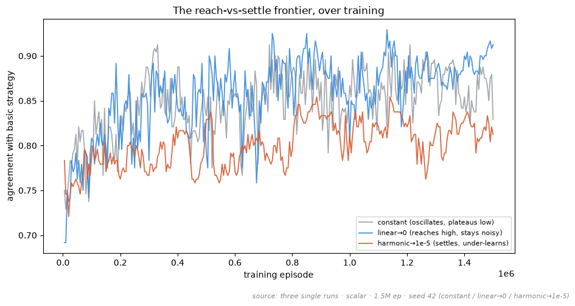

```python
def agreement_curve(path):
    return [(cp['episode'], cp['agreement']) for cp in learning_curve(path) if cp.get('agreement') is not None]

curves = [('constant (oscillates, plateaus low)', constant.iloc[0], '#9AA0A6'),
          ('linear→0 (reaches high, stays noisy)', reach.iloc[0],    '#378ADD'),
          ('harmonic→1e-5 (settles, under-learns)', settle.iloc[0],  '#D85A30')]
fig, ax = plt.subplots(figsize=(10, 5))
for label, row, col in curves:
    c = agreement_curve(row.path)
    ax.plot([e for e, _ in c], [a for _, a in c], color=col, lw=1.3, alpha=0.9, label=label)
ax.set_xlabel('training episode'); ax.set_ylabel('agreement with basic strategy')
ax.set_title('The reach-vs-settle frontier, over training')
ax.legend(fontsize=8, loc='lower right')
fignote('source: three single runs · scalar · 1.5M ep · seed 42 (constant / linear→0 / harmonic→1e-5)')
plt.show()
```

**Verdict — a symptom, not the cause.** Decaying the step settles the double, which is a real *variance* fix and gives us a keeper (a converging schedule). But the best-reaching run on this axis (linear) still trails the table, and pushing the step lower to settle the double *costs* agreement. We can beat the oscillation and the cap barely moves — because the residual is a **bias** (a wrong action in a few boundary cells), and no amount of variance reduction moves a bias. The frontier is the problem; Section 3.2 takes the *settle* route deliberately — a curriculum — and the data says it buys stability, not a higher ceiling.

## 3.2 Learning-order — the curriculum (flat-then-decay)

One thing to read correctly in the trajectory below: while the double is masked (before episode 500k) the agent simply *cannot* double, yet basic strategy doubles in **39 of the 240 cells (16%)** — so every one of those is forced wrong and agreement is **structurally capped at ~84%** during that phase. The flat low stretch is that ceiling, not a stalled learner. Once the double unmasks at 500k the agent has to learn the noisy new action from scratch, so there is a brief **dip** before the climb as those 39 cells come online — not a clean step up.

| config | agreement | edge | double-std |
| --- | --- | --- | --- |
| flat-then-decay (curriculum) | 87.1% | 1.21 | 0.12 |
| linear→0 (best reacher, 3.1) | 89.3% | 1.09 | 0.32 |

source: scalar · 1.5M ep · seed 42 — flat-then-decay single run; linear = mean over 4 runs

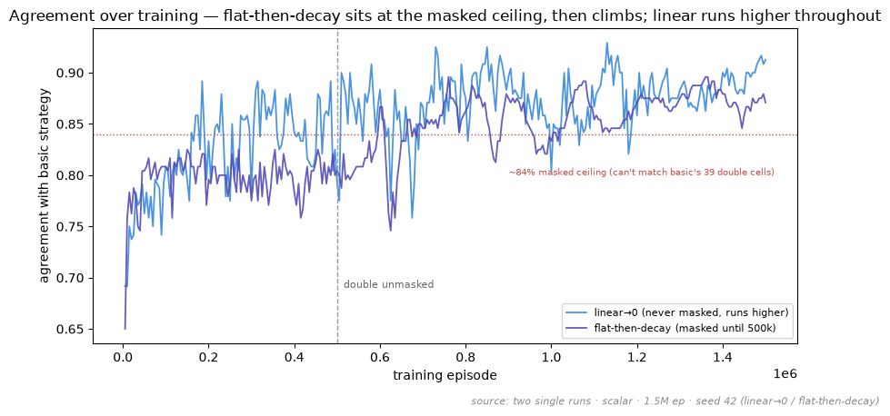

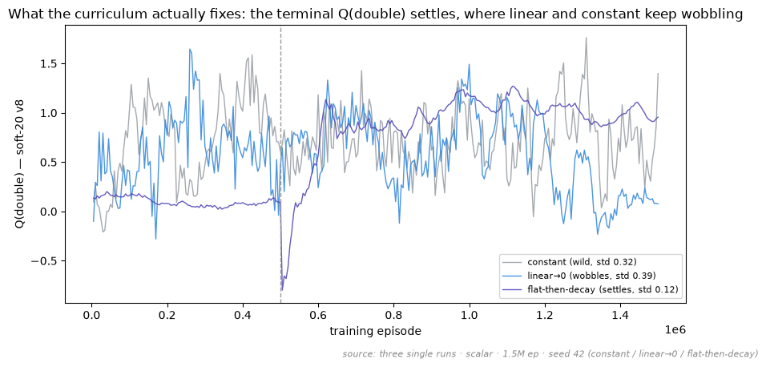

```python
ftd = d[(d.lr_hold_until>0) & (d.encoding=='scalar') & (d.episodes==1_500_000)]
comp = pd.DataFrame([
    {'config': 'flat-then-decay (curriculum)', 'agreement': ftd.agreement.mean(),  'edge': ftd.edge_pct.mean(),  'double-std': ftd.soft20_double_std.mean()},
    {'config': 'linear→0 (best reacher, 3.1)', 'agreement': reach.agreement.mean(), 'edge': reach.edge_pct.mean(), 'double-std': reach.soft20_double_std.mean()},
])
show(comp, pct=['agreement'], num=['edge', 'double-std'],
     caption='Flat-then-decay settles the double TIGHTEST of anything (double-std 0.12 vs 0.32) — and still '
             'trails linear on agreement (87.1% vs 89.3%). The curriculum buys stability, not a higher ceiling.',
     source='source: scalar · 1.5M ep · seed 42 — flat-then-decay single run; linear = mean over %d runs' % len(reach))

# Figure 1 — agreement over training, read honestly: the masked ceiling, then a dip-then-climb; linear runs higher throughout.
fig, ax = plt.subplots(figsize=(10, 4.5))
for label, row, col in [('linear→0 (never masked, runs higher)',  reach.iloc[0], '#378ADD'),
                        ('flat-then-decay (masked until 500k)',   ftd.iloc[0],   '#534AB7')]:
    c = agreement_curve(row.path)
    ax.plot([e for e, _ in c], [a for _, a in c], color=col, lw=1.3, alpha=0.9, label=label)
ax.axvline(500_000, ls='--', color='#999', lw=1); ax.text(515_000, 0.69, 'double unmasked', fontsize=8, color='#666')
ax.axhline(0.84, ls=':', color='#C0504D', lw=1)
ax.text(900000, 0.80, "~84% masked ceiling (can't match basic's 39 double cells)", fontsize=7.5, color='#C0504D')
ax.set_xlabel('training episode'); ax.set_ylabel('agreement with basic strategy')
ax.set_title('Agreement over training — flat-then-decay sits at the masked ceiling, then climbs; linear runs higher throughout')
ax.legend(fontsize=8, loc='lower right')
fignote('source: two single runs · scalar · 1.5M ep · seed 42 (linear→0 / flat-then-decay)')
plt.show()

# Figure 2 — the keeper, made visible: the terminal Q(double) SETTLES under the curriculum, where the others wobble.
def qd(path):
    return [(cp['episode'], cp['probe_q']['soft20_v8']['double'])
            for cp in learning_curve(path) if cp.get('probe_q') and 'soft20_v8' in cp.get('probe_q', {})]
fig, ax = plt.subplots(figsize=(10, 4.5))
for label, row, col in [('constant (wild, std 0.32)',     constant.iloc[0], '#9AA0A6'),
                        ('linear→0 (wobbles, std 0.39)',   reach.iloc[0],    '#378ADD'),
                        ('flat-then-decay (settles, std 0.12)', ftd.iloc[0], '#534AB7')]:
    q = qd(row.path)
    ax.plot([e for e, _ in q], [v for _, v in q], color=col, lw=1.0, alpha=0.9, label=label)
ax.axvline(500_000, ls='--', color='#999', lw=1)
ax.set_xlabel('training episode'); ax.set_ylabel('Q(double) — soft-20 v8')
ax.set_title('What the curriculum actually fixes: the terminal Q(double) settles, where linear and constant keep wobbling')
ax.legend(fontsize=8, loc='lower right')
fignote('source: three single runs · scalar · 1.5M ep · seed 42 (constant / linear→0 / flat-then-decay)')
plt.show()
```

## 3.3 Capacity — is the network the wrong size?

Two opposite worries: maybe the net is too *small* to represent the decision map, or maybe it needs more neurons than we gave it. A rule-count prior says small should be plenty — basic strategy is a *compact rule set* (a few dozen threshold rules; adjacent cells share an action), and a ReLU layer needs only about one boundary unit per rule. We check it two ways: a **matched sweep** where only the width changes, and the **full width range** in the naive regime.

```python
# --- A) matched sweep: only the network width changes (good stack, 1.5M) ---
sweep = d[(d.encoding=='onehot') & (d.lr_schedule=='harmonic') & (d.episodes==1_500_000)
          & (d.reward_baseline=='stand') & (d.double_after==500_000) & (d.double_dqn) & (d.seed==42)]
order = {'[8, 8]':0, '[16, 16]':1, '[64, 64]':2}
sz = (sweep[sweep.hidden.isin(order)].assign(o=lambda x: x.hidden.map(order)).sort_values('o')
      .groupby('hidden', sort=False)
      .agg(agreement=('agreement','mean'), edge=('edge_pct','mean'), **{'double-std':('soft20_double_std','mean')})
      .reset_index().rename(columns={'hidden':'network'}))
show(sz, pct=['agreement'], num=['edge', 'double-std'],
     caption='Matched sweep — only the width changes (good stack, 1.5M). [8,8] underfits; [16,16] (32 neurons) '
             'and [64,64] are a near dead heat (89.6% vs 90.0%). Thirty-two neurons already capture the map; '
             'four-times-wider adds nothing here.',
     source='source: onehot · harmonic 1e-3→1e-5 · stand-baseline · double@500k · Double-DQN · 1.5M ep · seed 42 — one run per size')

# --- B) the full width range in the naive regime (one canonical config) ---
import ast
naive = ((d.encoding=='scalar') & (d.lr_schedule=='constant') & (d.episodes==1_000_000) & (d.lr==1e-3)
         & (d.target_sync_every==1000) & (~d.double_dqn) & (~d.exploring_starts) & (d.train_every==4)
         & (d.reward_baseline=='none') & (d.double_after==0) & (d.target_tau==0) & (~d.swa))
big = d[naive & d.hidden.isin(['[8, 8]','[16, 16]','[32, 32]','[64, 64]','[64, 64, 64]','[128, 128]','[256, 256]'])].copy()
big['neurons'] = big.hidden.map(lambda h: sum(ast.literal_eval(h)))
bz = (big.sort_values('neurons').groupby(['hidden','neurons'], sort=False)
      .agg(n=('agreement','size'), agreement=('agreement','mean'), edge=('edge_pct','mean'),
           **{'double-std':('soft20_double_std','mean')}).reset_index().rename(columns={'hidden':'network'}))
b = big[big.hidden=='[64, 64]']
show(bz, pct=['agreement'], num=['edge', 'double-std'],
     caption='Full width range, naive regime (one canonical config; [64,64] run 3× across seeds). [64,64] alone '
             'spans %.1f–%.1f%% agreement across seeds — a ~%.0f-pt band that covers every size from [16,16] up; '
             '[8,8] underfits below it. Run-to-run noise, not width, sets these differences.'
             % (100*b.agreement.min(), 100*b.agreement.max(), 100*(b.agreement.max()-b.agreement.min())),
     source='source: scalar · constant lr 1e-3 · target_sync 1000 · 1M ep — [64,64] = 3 seeds (42–44); other sizes single runs (seed 42)')
print('edge carries the same seed noise: [64,64] over 3 seeds spans %.2f–%.2f%% (~%.2f pp), so the cross-size edge gaps sit inside the band too.'
      % (b.edge_pct.min(), b.edge_pct.max(), b.edge_pct.max()-b.edge_pct.min()))
```

Matched sweep — only the width changes (good stack, 1.5M). [8,8] underfits; [16,16] (32 neurons) and [64,64] are a near dead heat (89.6% vs 90.0%). Thirty-two neurons already capture the map; four-times-wider adds nothing here.

| network | agreement | edge | double-std |
| --- | --- | --- | --- |
| [8, 8] | 87.1% | 1.41 | 0.11 |
| [16, 16] | 89.6% | 1.23 | 0.06 |
| [64, 64] | 90.0% | 1.12 | 0.06 |

source: onehot · harmonic 1e-3→1e-5 · stand-baseline · double@500k · Double-DQN · 1.5M ep · seed 42 — one run per size

Full width range, naive regime (one canonical config; [64,64] run 3× across seeds). [64,64] alone spans 77.9–85.4% agreement across seeds — a ~7-pt band that covers every size from [16,16] up; [8,8] underfits below it. Run-to-run noise, not width, sets these differences.

| network | neurons | n | agreement | edge | double-std |
| --- | --- | --- | --- | --- | --- |
| [8, 8] | 16 | 1 | 72.9% | 2.99 | 0.24 |
| [16, 16] | 32 | 1 | 80.4% | 2.49 | 0.67 |
| [32, 32] | 64 | 1 | 82.5% | 1.76 | 0.43 |
| [64, 64] | 128 | 3 | 81.3% | 2.10 | 0.47 |
| [64, 64, 64] | 192 | 1 | 79.2% | 1.94 | 0.52 |
| [128, 128] | 256 | 1 | 82.9% | 1.53 | 0.44 |
| [256, 256] | 512 | 1 | 80.0% | 1.67 | 0.63 |

source: scalar · constant lr 1e-3 · target_sync 1000 · 1M ep — [64,64] = 3 seeds (42–44); other sizes single runs (seed 42)

```
edge carries the same seed noise: [64,64] over 3 seeds spans 1.66–2.72% (~1.07 pp), so the cross-size edge gaps sit inside the band too.
```

**Verdict — bigger isn't simply the answer; [16,16] fits the rule set.** At the budgets and seeds we have, more width past [16,16] does not buy a clear, repeatable gain — the cross-size differences sit *inside* the seed band on both agreement and edge. The one consistent signal is the other direction: **[8,8] (16 neurons) is too small** — it underfits in both regimes. So the sensible reading isn't "go bigger," it's **size the net to the problem**. Basic strategy is a few-dozen-rule map and a ReLU layer needs roughly one boundary unit per rule, so **[16,16] = 32 neurons** is a natural fit: small enough to be cheap, comfortably past [8,8]'s underfit. Capacity is not the binding cap.

What we do *not* claim: that [16,16] is uniquely optimal, or that width never matters at any budget. The longer [64,64] runs keep inching up with more training (back-half 88.4% → 89.5% → 91.1% across 1.5 / 2.5 / 5M), so the bigger net clearly has *headroom* extended training can use — we just lack matched [16,16] runs at those lengths to say whether the small net would track it, so we leave that open (Chapter 5 takes up training length directly). The load-bearing point here is the modest one: the function is small, a small net sized to the rules is the right tool, and "just make it bigger" is not the lesson.

## 3.4 Coverage — exploring starts

Maybe the boundary cells are simply *starved*: once the greedy policy commits and ε anneals, rare cells stop getting fresh data and drift. The fix is **exploring starts** — force every (state, action) to be a start state, so no cell can be under-sampled. If coverage were the cap, forcing it should clear the residual. It doesn't.

```python
# matched pair at the LONGEST exploring-starts budget we have (1.5M, good stack), not 1M: does forcing
# (state,action) coverage clear the residual? es ON vs OFF, everything else identical.
base = ((d.encoding=='scalar') & (d.hidden=='[64, 64]') & (d.lr_schedule=='linear') & (d.reward_baseline=='stand')
        & (d.double_dqn) & (d.episodes==1_500_000) & (d.batch==128) & (d.seed==42))
esT = d[base & d.exploring_starts]
esF = d[base & (~d.exploring_starts)]
def od(g):
    import json as _j; from pathlib import Path as _P
    overs = []
    for p in g.path:
        cells = _j.load(open(_P(p)/'record.json', encoding='utf-8'))['diff']['cells']
        overs.append(sum(1 for c in cells if c['category']=='genuine_disagreement'
                         and c['agent_action']=='double' and c['basic_action']!='double'))
    return st.mean(overs) if overs else float('nan')
cov = pd.DataFrame([
    {'setting': 'exploring starts ON',  'agreement': esT.agreement.mean(), 'edge': esT.edge_pct.mean(), 'over-doubles': od(esT)},
    {'setting': 'exploring starts OFF', 'agreement': esF.agreement.mean(), 'edge': esF.edge_pct.mean(), 'over-doubles': od(esF)},
])
show(cov, pct=['agreement'], num=['edge', 'over-doubles'],
     caption='Forcing uniform (state,action) coverage does NOT clear the residual — at 1.5M in the good stack it '
             'actively hurts: agreement falls (~91% → 86%), edge worsens, and the over-doubling roughly doubles '
             '(~10 → 24). Coverage is not the cap.',
     source='source: scalar · [64,64] · linear · stand-baseline · Double-DQN · 1.5M ep · seed 42 — es OFF (%d runs) vs ON (%d run)' % (len(esF), len(esT)))

# robustness across budgets + encodings: the over-double is the part that's CONSISTENT (agreement scatters
# within seed noise). Across every exploring-starts run, forced coverage keeps the over-double high — it
# never drops to the es-OFF good-stack level.
import json as _j; from pathlib import Path as _P
def _over(path):
    cells = _j.load(open(_P(path)/'record.json', encoding='utf-8'))['diff']['cells']
    return sum(1 for c in cells if c['category']=='genuine_disagreement' and c['agent_action']=='double' and c['basic_action']!='double')
all_es = sorted(_over(p) for p in d[d.exploring_starts].path)
print('over-doubles across all %d exploring-starts runs (1M+1.5M, both encodings): %s'
      % (len(all_es), all_es))
print('  median %.0f under forced coverage  vs  ~%.0f with es OFF in the good stack — coverage never clears the over-double.'
      % (st.median(all_es), od(esF)))
```

Forcing uniform (state,action) coverage does NOT clear the residual — at 1.5M in the good stack it actively hurts: agreement falls (~91% → 86%), edge worsens, and the over-doubling roughly doubles (~10 → 24). Coverage is not the cap.

| setting | agreement | edge | over-doubles |
| --- | --- | --- | --- |
| exploring starts ON | 85.8% | 1.31 | 24.00 |
| exploring starts OFF | 91.0% | 0.95 | 10.00 |

source: scalar · [64,64] · linear · stand-baseline · Double-DQN · 1.5M ep · seed 42 — es OFF (2 runs) vs ON (1 run)

```
over-doubles across all 6 exploring-starts runs (1M+1.5M, both encodings): [22, 23, 24, 24, 29, 30]
  median 24 under forced coverage  vs  ~10 with es OFF in the good stack — coverage never clears the over-double.
```

**Verdict — a null that rules *in* representation.** Forcing coverage doesn't help — and at the longest budget we have (1.5M, good stack) it actively *hurts*: agreement drops ~5 points and the over-doubling roughly doubles. The reason is telling. The network already has an answer at *every* cell (it generalizes), so there are no starved cells to fill; meanwhile exploring starts forces extra double-heavy start states, flooding the agent with the very high-variance `double` experience that drives the over-double bias. So coverage is a *table* problem (a lookup table only knows the cells it visited), not a network problem — and this null sharpens the target: the residual is in how the net *represents* the boundary, not in which cells it saw. (Generalization-vs-coverage returns as a headline in Chapter 7.)

## 3.5 Reward variance — a dealer control variate

Every hand pays **±2**, and most of that swing is the **dealer's** luck — the same dealer outcome is shared across hit, stand, and double, so it is *noise* with respect to which action you pick. The textbook remedy is a **control variate**: subtract a mean-zero, action-independent estimate of the dealer's contribution from the reward (here, the `--reward-baseline stand` flag). It is provably **unbiased** — expected value and the optimal policy are unchanged — and in principle it should make the learning signal cleaner, especially for the high-variance double. Does it actually help?

Two honest answers below: what the runs can (and *cannot*) tell us, and then *why* — mechanically — it can't move the one cell that matters.

```python
# (1) What a naive run comparison says — and why it is a trap.
stand = d[d.reward_baseline=='stand']; none = d[d.reward_baseline=='none']
gap = 100*(stand.agreement.mean() - none.agreement.mean())
print('Naive aggregate: stand-baseline averages %.1f%% agreement vs %.1f%% with no baseline — looks like +%.1f points.'
      % (100*stand.agreement.mean(), 100*none.agreement.mean(), gap))
print('But that gap is the STACK, not the baseline: the stand-baseline runs are ALSO the decaying-lr / curriculum /')
print('longer-trained ones. The baseline was never varied on its own, so there is no clean ablation to isolate it —')
print('and a +5-point "win" read off a correlated sweep is exactly the confound to distrust.')

# (2) Why it cannot help the cell that matters: where a doubled hand's +/-2 variance actually comes from.
import random
V = list(range(2, 11)) + [10, 10, 10] + [11]
def hv(cs):
    t, a = sum(cs), cs.count(11)
    while t > 21 and a: t -= 10; a -= 1
    return t
def dealer(up, rng):
    c = [up, rng.choice(V)]
    while hv(c) < 17: c.append(rng.choice(V))
    t = hv(c); return 0 if t > 21 else t
def rew(pf, dl): return -1.0 if pf > 21 else (1.0 if dl == 0 else (1.0 if pf > dl else (-1.0 if pf < dl else 0.0)))
def decomp(start, up, n=120_000):
    rng = random.Random(0); rows = []
    for _ in range(n):
        pf = hv(start + [rng.choice(V)]); dl = dealer(up, rng); rows.append((2*rew(pf, dl), pf, dl))
    r = [x[0] for x in rows]; var = st.pvariance(r); mu = st.mean(r)
    def expl(k):
        g = {}
        for x in rows: g.setdefault(k(x), []).append(x[0])
        return sum(len(v)*(st.mean(v)-mu)**2 for v in g.values())/len(rows)/var
    return expl(lambda x: x[2]), expl(lambda x: x[1])   # dealer-share, player-draw-share
vd = pd.DataFrame([dict(zip(['double cell', 'dealer (CV cancels this)', 'player draw (intrinsic)'],
        [n] + list(decomp(c, u)))) for n, c, u in [('soft-20 v8', [11,9], 8), ('hard-11 v6', [5,6], 6), ('hard-16 v10', [10,6], 10)]])
show(vd, pct=['dealer (CV cancels this)', 'player draw (intrinsic)'],
     caption="Where a doubled hand's ±2 variance comes from. The control variate can cancel only the DEALER "
             "column; the player-draw column is the agent's own one-card draw — intrinsic, uncancellable. On the "
             "double the dealer is the MINORITY of the variance, so the control variate leaves most of the noise standing.",
     source='source: analytic Monte-Carlo of the hand model, 120k draws/cell — not a training run')
```

```
Naive aggregate: stand-baseline averages 87.6% agreement vs 82.0% with no baseline — looks like +5.5 points.
But that gap is the STACK, not the baseline: the stand-baseline runs are ALSO the decaying-lr / curriculum /
longer-trained ones. The baseline was never varied on its own, so there is no clean ablation to isolate it —
and a +5-point "win" read off a correlated sweep is exactly the confound to distrust.
```

| double cell | dealer (CV cancels this) | player draw (intrinsic) |
| --- | --- | --- |
| soft-20 v8 | 34.4% | 41.5% |
| hard-11 v6 | 45.7% | 25.5% |
| hard-16 v10 | 9.7% | 62.7% |

source: analytic Monte-Carlo of the hand model, 120k draws/cell — not a training run

**Verdict — an honest null (a correct tool aimed at the wrong variance).** The control variate is *right*: unbiased, EV-preserving, and it genuinely cancels the dealer's share of the noise. But that share is not where the trouble is. The cell that actually misbehaves — the terminal double — is dominated by the **player's own one-card draw**, which is intrinsic and which no action-independent baseline can touch. So the technique quiets noise we did not need quieted and cannot reach the noise we did.

And because the baseline only ever ran *inside* the stack, its standalone effect can't even be measured — the +5-point aggregate is the stack talking, not the baseline. Two takeaways, neither a keeper: a **mechanism** (match a variance-reduction tool to the actual variance source, or it does nothing where you need it) and a **discipline** (an effect read off a correlated sweep will mislead — trust matched comparisons, not aggregates).

## 3.6 The standard knobs

Finally, the usual DQN add-ons — Double-DQN, batch size, weight averaging (SWA), a soft target. Each is a reasonable idea, and a couple are mildly, consistently positive. But the decisive fact is the **seed band**: rerun the *same* naive config at different seeds and agreement swings ~8 points on its own. Every single-knob effect we can isolate lives *inside* that band — so no one of them closes the naive→tabular gap, and you cannot even conclude a knob "works" from a single comparison. The recovery is the **stack**, not a lever.

```python
naive_band = d[(d.encoding=='onehot') & (d.lr_schedule=='constant') & (d.episodes==1_000_000)
               & (d.reward_baseline=='none') & (d.double_after==0) & (~d.swa)]
band = 100*(naive_band.agreement.max() - naive_band.agreement.min())

CTRL = ['encoding','lr_schedule','episodes','lr','lr_end','reward_baseline','double_after','lr_hold_until','batch']
def bool_effect(knob):
    deltas=[]
    for _, g in d.groupby(CTRL, dropna=False):
        m = g.groupby(knob).agreement.mean()
        if {True, False} <= set(m.index): deltas.append(100*(m[True]-m[False]))
    return (st.mean(deltas), len(deltas)) if deltas else (float('nan'), 0)
ddqn = bool_effect('double_dqn'); swa = bool_effect('swa')
tau_on = d[d.target_tau>0].soft20_double_std.dropna().mean(); tau_off = d[(d.target_tau==0)&(d.lr_schedule=='constant')&(d.encoding=='onehot')].soft20_double_std.dropna().mean()
knobs = pd.DataFrame([
    {'knob': 'Double-DQN', 'mean Δ agreement (matched)': ddqn[0], 'within seed band?': 'yes'},
    {'knob': 'SWA (weight averaging)', 'mean Δ agreement (matched)': swa[0], 'within seed band?': 'yes'},
])
show(knobs, num=['mean Δ agreement (matched)'],
     caption='Matched single-knob effects on agreement (averaged over every context where only that knob '
             'varies). Both are mildly positive on average (the table shows each) and both fit inside the '
             '%.0f-point seed band — so neither alone closes the gap.' % band,
     source='source: all no-split DQN runs, matched within-config pairs (Double-DQN: %d contexts, SWA: %d)' % (ddqn[1], swa[1]))
print('seed band (same naive config, seeds %s): %.1f points — as large as the best single-knob effect'
      % (sorted(set(naive_band.seed.dropna())), band))
print('soft target (tau): double-std %.2f on vs %.2f off — inert (Ch2), not a knob worth turning' % (tau_on, tau_off))
print('batch size: mixed across contexts (64→512 helped once +6pts, 128→512 hurt once −2.5pts) — inside the band')
```

Matched single-knob effects on agreement (averaged over every context where only that knob varies). Both are mildly positive on average (the table shows each) and both fit inside the 8-point seed band — so neither alone closes the gap.

| knob | mean Δ agreement (matched) | within seed band? |
| --- | --- | --- |
| Double-DQN | 1.63 | yes |
| SWA (weight averaging) | 3.61 | yes |

source: all no-split DQN runs, matched within-config pairs (Double-DQN: 5 contexts, SWA: 2)

```
seed band (same naive config, seeds [42, 43, 44]): 8.3 points — as large as the best single-knob effect
soft target (tau): double-std 0.65 on vs 0.77 off — inert (Ch2), not a knob worth turning
batch size: mixed across contexts (64→512 helped once +6pts, 128→512 hurt once −2.5pts) — inside the band
```

## 3.7 Conclusion — six suspects, six verdicts

Settling, learning-order, capacity, coverage, reward variance, the standard knobs: every fixable, training-side explanation tested and ruled out as *the* cause. Three left a real method — a converging schedule, a curriculum that buys stability, and a right-sized [16,16] network — and three left a clean fact: coverage doesn't bind a model that generalizes, the control variate is inert on the intrinsic-variance double, and no single knob escapes the seed band. Through every one of them the residual keeps the **same fingerprint**: over-doubling, one direction, concentrated in a handful of low-margin boundary cells. That is the signature of a **bias**, not variance, under-training, or starvation — and a bias in specific cells is a property of how the function approximator *represents* the decision map. Chapter 4 looks straight at that representation, and finds the errors exactly where it predicts.

# Chapter 4 — The real cause: representation

Chapter 3 ruled out every *fixable* training cause — settling, curriculum, capacity, coverage, reward variance, the standard knobs. What survives is a one-directional **over-doubling bias** in a handful of boundary cells. By now the oscillation is *cured* and training is *long* (5M episodes), so the residual is neither variance nor under-training; a bias in *specific cells* is a statement about how the network **represents** the map.

The finding, in one line: **the smooth network learns everything the problem needs — the ordinal structure, the whole hit/stand map — except a sharp wall at the double's edge. That one missing wall is the entire residual, and the input encoding is a dial for how much of it you can buy back.** We show it three ways: where the errors sit (§4.1), the geometry that puts them there (§4.2), and the dial that moves them (§4.3).

## 4.1 The residual is settled — a soft edge on the double

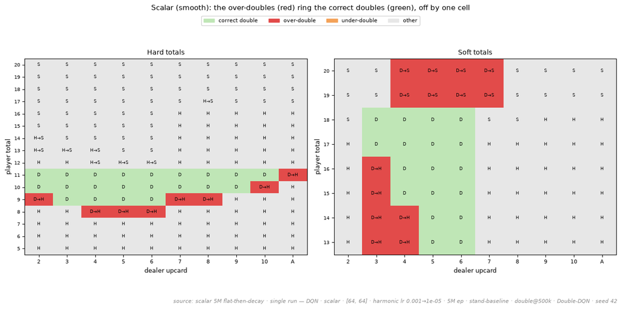

```
Q(double) soft-20 v8 back-half std = 0.16  (Ch2 naive was 1.14 — now settled)  |  21 of 23 genuine disagreements are over-doubles
```

```python
import sys; sys.path.insert(0, '.')
import json as _j, statistics as st
from pathlib import Path as _P
import numpy as np
import matplotlib.pyplot as plt
from matplotlib.colors import ListedColormap
import matplotlib.patches as mpatches
from runs import load_runs, learning_curve, show, provenance, fignote, describe

df = load_runs(); dqn = df[df.has_model & (df.method == 'dqn')]
RUN = dqn[(dqn.encoding == 'scalar') & (dqn.lr_hold_until > 0) & (dqn.episodes == 5_000_000)].iloc[0]
cells = _j.load(open(_P(RUN.path) / 'record.json', encoding='utf-8'))['diff']['cells']

UP = list(range(2, 12))
ACT = {'hit': 'H', 'stand': 'S', 'double': 'D'}
DCOL = ['#bfe6b6', '#e24b4a', '#f4a259', '#e7e7e7']   # 0 correct double, 1 over, 2 under, 3 other
dcmap = ListedColormap(DCOL)
def dcat(c):
    a, b = c['agent_action'], c['basic_action']
    if b == 'double' and a == 'double': return 0
    if b != 'double' and a == 'double': return 1   # over-double
    if b == 'double' and a != 'double': return 2   # under-double
    return 3
def dpanel(ax, clist, is_soft, title):
    vals = sorted({c['player_value'] for c in clist if c['is_soft'] == is_soft}, reverse=True)
    G = np.full((len(vals), len(UP)), np.nan)
    for c in clist:
        if c['is_soft'] != is_soft: continue
        i, j = vals.index(c['player_value']), UP.index(c['dealer_upcard'])
        G[i, j] = dcat(c)
        lab = ACT.get(c['agent_action'], '?')
        if c['agent_action'] != c['basic_action']:
            lab = '%s→%s' % (ACT.get(c['agent_action'], '?'), ACT.get(c['basic_action'], '?'))
        ax.text(j, i, lab, ha='center', va='center', fontsize=6.5)
    ax.imshow(G, cmap=dcmap, vmin=0, vmax=3, aspect='auto')
    ax.set_xticks(range(len(UP))); ax.set_xticklabels([str(u) if u < 11 else 'A' for u in UP], fontsize=8)
    ax.set_yticks(range(len(vals))); ax.set_yticklabels(vals, fontsize=7)
    ax.set_xlabel('dealer upcard', fontsize=9); ax.set_ylabel('player total', fontsize=9); ax.set_title(title, fontsize=10)
def dgrid(clist, run_row, suptitle):
    fig, axes = plt.subplots(1, 2, figsize=(13, 6))
    dpanel(axes[0], clist, False, 'Hard totals'); dpanel(axes[1], clist, True, 'Soft totals')
    handles = [mpatches.Patch(color=DCOL[0], label='correct double'), mpatches.Patch(color=DCOL[1], label='over-double'),
               mpatches.Patch(color=DCOL[2], label='under-double'), mpatches.Patch(color=DCOL[3], label='other')]
    fig.legend(handles=handles, loc='upper center', ncol=4, fontsize=8, framealpha=0.9, bbox_to_anchor=(0.5, 0.97))
    fig.suptitle(suptitle, y=1.0, fontsize=11)
    plt.tight_layout(rect=[0, 0.04, 1, 0.92]); fignote(provenance(run_row, role='%s 5M flat-then-decay' % run_row.encoding)); plt.show()

dgrid(cells, RUN, "Scalar (smooth): the over-doubles (red) ring the correct doubles (green), off by one cell")
dd = [cp['probe_q']['soft20_v8']['double'] for cp in learning_curve(RUN.path) if cp.get('probe_q') and 'soft20_v8' in cp.get('probe_q', {})]
gen = [c for c in cells if c['category'] == 'genuine_disagreement']
over = sum(1 for c in gen if c['agent_action'] == 'double' and c['basic_action'] != 'double')
print('Q(double) soft-20 v8 back-half std = %.2f  (Ch2 naive was 1.14 — now settled)  |  %d of %d genuine disagreements are over-doubles'
      % (st.pstdev(dd[len(dd)//2:]), over, len(gen)))
```

## 4.2 Two geometries — the smooth net has everything but the wall

*A note on projection.* The **action** view uses **PCA** — the hit→double→stand decision is a *global* ordering that PCA's linear axes preserve and t-SNE tends to fragment into islands. The other four views (category, margin, soft/hard, upcard) use **t-SNE**, which separated the local clusters and the error seam more clearly here. Different tools for global structure vs local clusters — not a projection picked to flatter each claim.

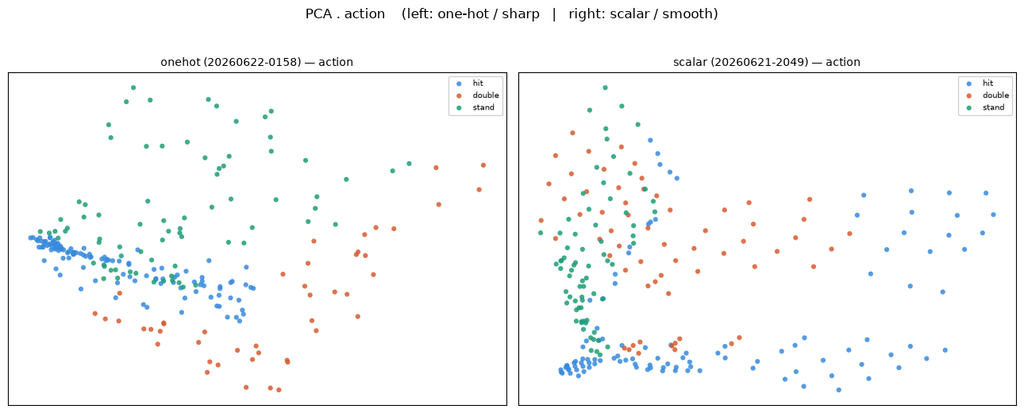

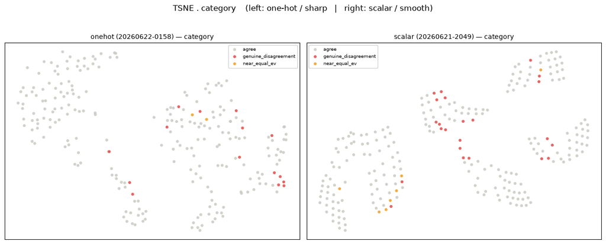

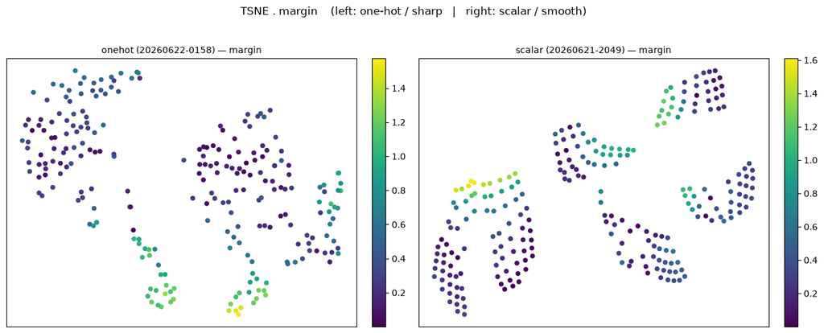

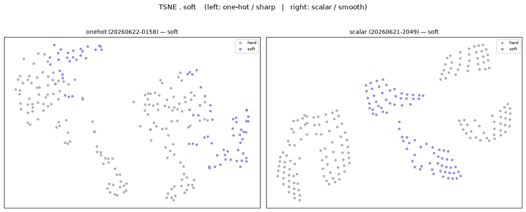

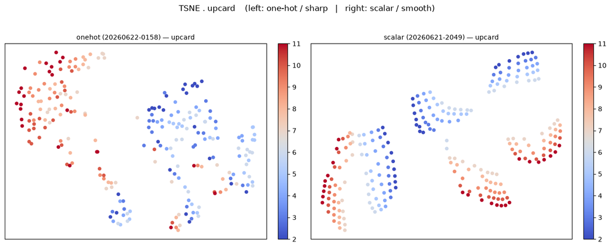

[output not shown]

```python
ROOT = next(p for p in [_P.cwd(), *_P.cwd().parents] if (p / 'blackjack_rl').is_dir())
if str(ROOT) not in sys.path: sys.path.insert(0, str(ROOT))
from blackjack_rl.evaluation.embedding import load_agent, cell_embeddings
from sklearn.decomposition import PCA
from sklearn.manifold import TSNE
from sklearn.metrics import silhouette_score

A = dqn[(dqn.encoding == 'onehot') & (dqn.lr_hold_until > 0) & (dqn.episodes == 5_000_000)].iloc[0]  # sharp / categorical
B = RUN                                                                                              # smooth / ordinal (scalar, from 4.1)
def embed(row):
    ce = cell_embeddings(load_agent(row.path)); X = np.array(ce.embeddings)
    return dict(label='%s (%s)' % (row.encoding, row.run[:13]), cells=ce.cells, X=X,
                pca=PCA(n_components=2).fit_transform(X),
                tsne=TSNE(n_components=2, perplexity=30, init='pca', random_state=0).fit_transform(X))
EA, EB = embed(A), embed(B)

ACOL = {'hit': '#378ADD', 'stand': '#1D9E75', 'double': '#D85A30'}
CAT  = {'agree': '#CBCBC4', 'near_equal_ev': '#EF9F27', 'genuine_disagreement': '#E24B4A'}
SOFTC = {'soft': '#7F77DD', 'hard': '#9AA0A6'}
PAL  = {'action': ACOL, 'category': CAT, 'soft': SOFTC}
KEY  = {'action': lambda c: c['action'], 'category': lambda c: c['category'], 'soft': lambda c: 'soft' if c['is_soft'] else 'hard'}
CONT = {'margin': ('q_margin', 'viridis'), 'upcard': ('dealer_upcard', 'coolwarm')}
def scat(ax, P, labels, colors, title):
    for lab in dict.fromkeys(labels):
        m = [i for i, l in enumerate(labels) if l == lab]
        ax.scatter(P[m, 0], P[m, 1], s=20, c=colors.get(lab, '#888'), label=str(lab), edgecolor='none', alpha=0.85)
    ax.set_title(title, fontsize=10); ax.set_xticks([]); ax.set_yticks([]); ax.legend(fontsize=7, framealpha=0.9)
def compare(kind, proj):
    fig, ax = plt.subplots(1, 2, figsize=(13, 5))
    for j, E in enumerate([EA, EB]):
        P = E[proj]
        if kind in CONT:
            field, cmap = CONT[kind]
            sc = ax[j].scatter(P[:, 0], P[:, 1], s=20, c=[c[field] for c in E['cells']], cmap=cmap)
            ax[j].set_title('%s — %s' % (E['label'], kind), fontsize=10); ax[j].set_xticks([]); ax[j].set_yticks([])
            fig.colorbar(sc, ax=ax[j], fraction=0.046, pad=0.04)
        else:
            scat(ax[j], P, [KEY[kind](c) for c in E['cells']], PAL[kind], '%s — %s' % (E['label'], kind))
    fig.suptitle('%s . %s    (left: one-hot / sharp   |   right: scalar / smooth)' % (proj.upper(), kind), y=1.03)
    plt.tight_layout(); plt.show()

compare('action', 'pca')                       # global hit->double->stand ordering: PCA keeps it, t-SNE fragments it
for k in ['category', 'margin', 'soft', 'upcard']:
    compare(k, 'tsne')                         # local clusters + the error seam: t-SNE separates them more clearly

def sil(E, key):
    labs = [key(c) for c in E['cells']]; code = {a: i for i, a in enumerate(dict.fromkeys(labs))}
    return silhouette_score(E['X'], [code[l] for l in labs])
print('ORDINAL STRUCTURE (silhouette on the full embedding; higher = the ordered feature is laid out as clean structure):')
print('  %-22s%12s%10s' % ('', 'soft/hard', 'upcard'))
for E in [EA, EB]:
    print('  %-22s%+12.3f%+10.3f' % (E['label'][:22], sil(E, lambda c: c['is_soft']), sil(E, lambda c: c['dealer_upcard'])))
m_a = [c['q_margin'] for c in EB['cells'] if c['category'] == 'agree']
m_d = [c['q_margin'] for c in EB['cells'] if c['category'] == 'genuine_disagreement']
print('\nERRORS ON THE SEAM (scalar): mean margin  agree %.2f  vs  disagree %.2f (razor-edge).' % (np.mean(m_a), np.mean(m_d)))
print('scalar leads the structure rows (smooth ordinal axes); one-hot scrambles them but draws the sharper double boundary.')
```

## 4.3 The dial — how much wall you can buy

If the residual is one missing wall, a *sharper* input should build some of it back. One-hot treats each total / upcard as its own slot, so it can place a **hard edge** between adjacent cells instead of ramping across them. Same network, schedule, and 5M budget — only the encoding differs. The same double-focused grid, now for one-hot, makes it visual; the table puts numbers on it.

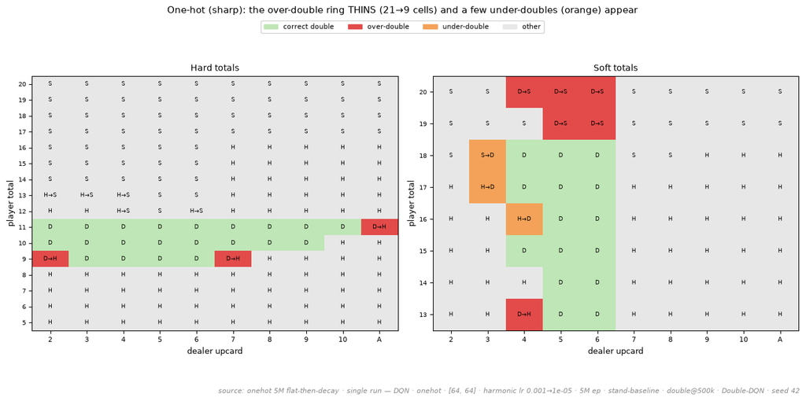

```python
# the SAME double-focused grid (reusing dgrid from 4.1), now for ONE-HOT — compare to the scalar grid above
A = dqn[(dqn.encoding == 'onehot') & (dqn.lr_hold_until > 0) & (dqn.episodes == 5_000_000)].iloc[0]
oh_cells = _j.load(open(_P(A.path) / 'record.json', encoding='utf-8'))['diff']['cells']
dgrid(oh_cells, A, "One-hot (sharp): the over-double ring THINS (21→9 cells) and a few under-doubles (orange) appear")
```

Turn the dial to SHARP (one-hot) and the over-doubles more than halve (21 → 9) — the direct test of the smoothness diagnosis. Here the residual IS a boundary problem, so one-hot wins both agreement and edge; the price is a couple of under-doubles (no neighbour to interpolate a double in from).

| encoding | agreement | edge | over-doubles | under-doubles |
| --- | --- | --- | --- | --- |
| one-hot (sharp) | 92.9% | 0.90 | 9 | 3 |
| scalar (smooth) | 87.5% | 1.25 | 21 | 0 |

source: matched 5M flat-then-decay (onehot vs scalar), [64,64] · stand · double@500k · Double-DQN · seed 42

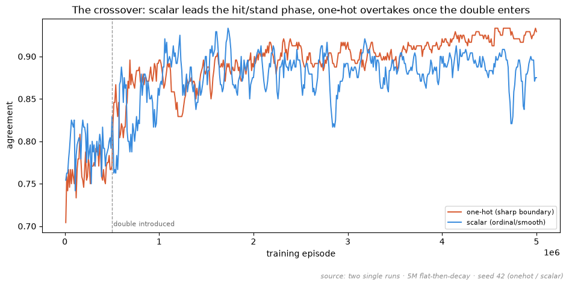

```python
def breakdown(path):
    dc = _j.load(open(_P(path) / 'record.json', encoding='utf-8'))['diff']['cells']
    dis = [c for c in dc if c['category'] == 'genuine_disagreement']
    over = sum(1 for c in dis if c['agent_action'] == 'double' and c['basic_action'] != 'double')
    under = sum(1 for c in dis if c['basic_action'] == 'double' and c['agent_action'] != 'double')
    return len(dis), over, under

import pandas as pd
rows = []
for tag, R in [('one-hot (sharp)', A), ('scalar (smooth)', RUN)]:
    g, o, u = breakdown(R.path)
    rows.append({'encoding': tag, 'agreement': R.agreement, 'edge': R.edge_pct, 'over-doubles': o, 'under-doubles': u})
show(pd.DataFrame(rows), pct=['agreement'], num=['edge'],
     caption='Turn the dial to SHARP (one-hot) and the over-doubles more than halve (21 → 9) — the direct test of the '
             'smoothness diagnosis. Here the residual IS a boundary problem, so one-hot wins both agreement and edge; '
             'the price is a couple of under-doubles (no neighbour to interpolate a double in from).',
     source='source: matched 5M flat-then-decay (onehot vs scalar), [64,64] · stand · double@500k · Double-DQN · seed 42')

def agreement_curve(path):
    return [(cp['episode'], cp['agreement']) for cp in learning_curve(path) if cp.get('agreement') is not None]
fig, ax = plt.subplots(figsize=(9.5, 4.5))
for tag, R, col in [('one-hot (sharp boundary)', A, '#D85A30'), ('scalar (ordinal/smooth)', RUN, '#378ADD')]:
    c = agreement_curve(R.path)
    ax.plot([e for e, _ in c], [a for _, a in c], color=col, lw=1.4, label=tag)
ax.axvline(500_000, ls='--', color='#999', lw=1); ax.text(515_000, 0.70, 'double introduced', fontsize=8, color='#666')
ax.set_xlabel('training episode'); ax.set_ylabel('agreement'); ax.legend(fontsize=8, loc='lower right')
ax.set_title('The crossover: scalar leads the hit/stand phase, one-hot overtakes once the double enters')
fignote('source: two single runs · 5M flat-then-decay · seed 42 (onehot / scalar)'); plt.tight_layout(); plt.show()
```

- **scalar = smooth / ordinal** — clean ordered axes and interpolation across neighbours: strong structure and rare-cell generalization, but a *soft* double boundary, so it over-doubles at the seam.
- **one-hot = categorical / sharp** — hard walls between adjacent cells: half the over-doubles, at the cost of the ordinal structure (a few under-doubles, weaker generalization).

Which end wins is decided by what the residual *is*. For Problem A it is the double's soft edge, so sharp wins. The point is not "one-hot is better" — it is that **the error was one missing wall**, and the dial controls how much of it you build.

## 4.4 Conclusion — the floor is one wall

The residual is not instability (cured, Ch2–3), not under-training (5M), not coverage or reward variance (Ch3). It is the **one boundary a smooth approximator cannot make sharp**: the double's edge. A continuous representation places adjacent cells side by side and *interpolates*, so a step that should be a wall becomes a ramp, and the cells on the ramp fall to the wrong side — the over-doubles. The embedding shows them on the low-margin seam; the encoding dial confirms it — sharpen the input and half the wall returns.

This closes the loop with Chapter 1. A lookup table is *all* wall: every cell independent, every boundary hard, zero tuning — which is exactly why it wins on **agreement-exactness**. The network's gap is the softness of that one edge. But on **edge** — the metric that costs money — a sharp-enough (one-hot) net draws it clean enough to match or beat the table. So the gap that remains is a **representation choice (how much wall you build), not a limit on what the network can learn**. Chapter 7 returns here as the project's spine — the three axes of Chapter 1's decision-tree frame, now earned.

# Chapter 5 — Honesty and dynamics

Two earlier chapters left a promissory note here. Chapter 1 (§1.2) flagged *"a run that shrank its self-gap while its edge stood still"*; Chapter 3 (§3.3) deferred the question of **training length** to this chapter. Both come due now — and both turn out to be the same kind of story.

This chapter is not about a new result. It is about **measurement**: the two ways our own metrics tried to flatter us, and the discipline that caught them before they reached the headline. The function-approximation floor of Chapter 4 is still the floor; what follows is how we kept ourselves from claiming more than the floor allows.

## 5.1 — A metric that graded its own homework

The diff doesn't just count matches against basic strategy. It splits every *disagreement* into two kinds, using the agent's **own** Q-values:

- **genuine disagreement** — the agent's network clearly prefers its action over basic's (a wide self-estimated EV gap);
- **near-tie** (`near_equal_ev`) — by the agent's own estimate the two actions are within an EV tolerance, too close to call.

That split is useful, but it has a trap built in. As Q-values converge with longer training, the agent's self-estimated gaps **shrink** — and cells that were genuine disagreements slide under the tolerance and get re-labelled near-ties. The diff looks cleaner. Nothing was fixed.

Here is the matched pair Chapter 1 promised: the *same* agent and seed, trained 1.5M vs 5M episodes — only the length differs.

Train the same agent 3.3x longer: the disagreement count falls, the edge does not

| training | agree_cells | genuine | near_tie | self_gap | agreement | edge_pct |
| --- | --- | --- | --- | --- | --- | --- |
| 1.5M ep | 209 | 28 | 3 | 0.29 | 87.1% | 1.21 |
| 5M ep | 210 | 23 | 7 | 0.28 | 87.5% | 1.25 |

source: matched pair, identical config & seed, length is the only difference — DQN · scalar · [64, 64] · harmonic · Double-DQN · stand-baseline · double@500k · seed 42

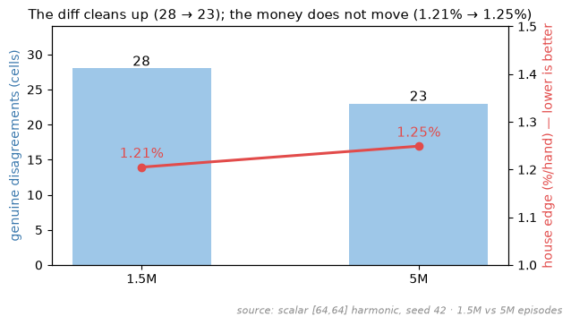

```python
import sys; sys.path.insert(0, '.')
import json as _j
from pathlib import Path as _P
from collections import Counter
import numpy as np, pandas as pd
import matplotlib.pyplot as plt
from runs import load_runs, learning_curve, show, provenance, fignote, describe

df = load_runs(); dqn = df[df.method == 'dqn']

# matched pair: identical config & seed, training length is the ONLY difference
def _pick(ep):
    s = dqn[(dqn.encoding == 'scalar') & (dqn.hidden == '[64, 64]') & (dqn.lr_schedule == 'harmonic')
            & dqn.double_dqn & (dqn.reward_baseline == 'stand') & (dqn.double_after > 0)
            & (dqn.episodes == ep) & (dqn.seed == 42)]
    return s.iloc[0]
short, long_ = _pick(1_500_000), _pick(5_000_000)

def _selfgap(row):
    cells = _j.load(open(_P(row.path) / 'record.json', encoding='utf-8'))['diff']['cells']
    cnt = Counter(c['category'] for c in cells)
    gen = [c for c in cells if c['category'] == 'genuine_disagreement']
    sg = float(np.mean([abs(c['agent_q'] - c['basic_q']) for c in gen]))  # mean self-estimated EV gap
    return dict(training='%gM ep' % (row.episodes / 1e6), agree_cells=cnt['agree'],
                genuine=cnt['genuine_disagreement'], near_tie=cnt['near_equal_ev'],
                self_gap=sg, agreement=row.agreement, edge_pct=row.edge_pct)

tab = pd.DataFrame([_selfgap(short), _selfgap(long_)])
show(tab, pct=['agreement'], num=['self_gap', 'edge_pct'],
     caption='Train the same agent 3.3x longer: the disagreement count falls, the edge does not',
     source='source: matched pair, identical config & seed, length is the only difference — '
            'DQN · scalar · [64, 64] · harmonic · Double-DQN · stand-baseline · double@500k · seed 42')

# the divergence, drawn: genuine-disagreement count drops while edge holds
fig, ax1 = plt.subplots(figsize=(6.4, 3.4))
x = [0, 1]; lbl = ['1.5M', '5M']
ax1.bar(x, tab.genuine, width=0.5, color='#9ec7e8', label='genuine disagreements')
for xi, v in zip(x, tab.genuine): ax1.text(xi, v + 0.4, str(int(v)), ha='center', fontsize=11)
ax1.set_ylabel('genuine disagreements (cells)', color='#3a78ad')
ax1.set_xticks(x); ax1.set_xticklabels(lbl); ax1.set_ylim(0, 34)
ax2 = ax1.twinx()
ax2.plot(x, tab.edge_pct, '-o', color='#e24b4a', lw=2.2, label='house edge')
for xi, v in zip(x, tab.edge_pct): ax2.text(xi, v + 0.02, '%.2f%%' % v, ha='center', color='#e24b4a', fontsize=11)
ax2.set_ylabel('house edge (%/hand) — lower is better', color='#e24b4a'); ax2.set_ylim(1.0, 1.5)
ax1.set_title('The diff cleans up (28 → 23); the money does not move (1.21% → 1.25%)', fontsize=11)
fignote('source: scalar [64,64] harmonic, seed 42 · 1.5M vs 5M episodes')
plt.tight_layout(); plt.show()
```

**Reading it.** Five genuine disagreements (28 → 23) vanished from the "genuine" column — and four of them reappeared as near-ties (3 → 7). The agent's mean self-gap on the cells it still disagrees on shrank (0.29 → 0.28). Every aggregate that the agent computes *about itself* says the diff got cleaner.

But the agent plays those cells exactly as before. The proof is in the two metrics that face the ruler, not the agent: the house **edge** did not improve (1.21% → 1.25%, if anything a hair worse) and **agreement** is flat (0.871 → 0.875). Longer training made the agent *more confident that its mistakes weren't mistakes* — it did not make them stop being mistakes.

The lesson is a rule for the rest of the report: **the self-gap and the genuine/near split measure the agent's certainty, not its correctness.** Trust the edge (money lost against basic on the same hands) and agreement (action-match against the proven-optimal ruler). Distrust any number computed from the agent's own Q-values — it grades its own homework.

## 5.2 — The peak that wasn't a home

Now the training-length question Chapter 3.3 deferred. Watch evaluation agreement over a long run and you don't see a tidy climb to a final value. You see it **spike** to a high-water mark early or mid-run, then settle onto a lower plateau and stay there. The peak is a transient — a lucky alignment of borderline cells — not a level the model holds.

```python
five = dqn[(dqn.episodes == 5_000_000) & (~dqn.with_splits)].copy()

def _dyn(row):
    lc = learning_curve(row.path)
    pts = [(cp['episode'], cp['agreement']) for cp in lc if 'agreement' in cp]
    eps = np.array([p[0] for p in pts]); ag = np.array([p[1] for p in pts]); mx = eps.max()
    bh = ag[eps > mx / 2]
    enc = '%s %s' % (row.encoding, row.hidden)
    return dict(config=enc, episodes='%gM' % (row.episodes / 1e6),
                peak=float(ag.max()), peak_at='%.1fM' % (eps[ag.argmax()] / 1e6),
                back_half=float(bh.mean()), peak_minus_plateau=float(ag.max() - bh.mean()))

rows = [_dyn(r) for _, r in five.iterrows()]
# the longest run we have: 10M episodes (the split-aware agent of Ch6) — a different game, shown softly
ten = dqn[(dqn.episodes == 10_000_000)]
if len(ten):
    d = _dyn(ten.iloc[0]); d['config'] += ' (+splits, 10M)'; rows.append(d)

tab2 = pd.DataFrame(rows).sort_values('back_half', ascending=False)
show(tab2, pct=['peak', 'back_half', 'peak_minus_plateau'],
     caption='Single-checkpoint peak vs the steady back-half level it never sustains',
     source='source: each row a single 5M run (one seed) · peak = best checkpoint, back_half = mean over the '
            'final half of training · last row is the 10M split-aware run (Problem of Ch6), shown for length only')
```

Single-checkpoint peak vs the steady back-half level it never sustains

| config | episodes | peak | peak_at | back_half | peak_minus_plateau |
| --- | --- | --- | --- | --- | --- |
| onehot [64, 64] | 5M | 93.3% | 4.6M | 91.1% | 2.3% |
| scalar [64, 64] | 5M | 93.3% | 1.7M | 88.5% | 4.9% |
| onehot [16, 16] | 5M | 92.1% | 0.7M | 87.3% | 4.7% |
| onehot [16, 16] (+splits, 10M) | 10M | 87.4% | 4.9M | 84.7% | 2.6% |
| onehot [256, 256] | 5M | 89.2% | 3.0M | 84.1% | 5.1% |

source: each row a single 5M run (one seed) · peak = best checkpoint, back_half = mean over the final half of training · last row is the 10M split-aware run (Problem of Ch6), shown for length only

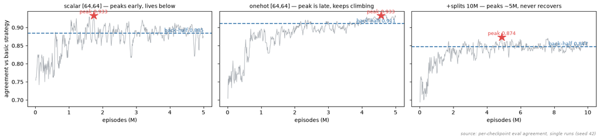

```python
# the shape, drawn: an early-peaking run and the 10M run — peak (star) sits above the back-half band
def _trace(row):
    lc = learning_curve(row.path)
    pts = [(cp['episode'], cp['agreement']) for cp in lc if 'agreement' in cp]
    return np.array([p[0] for p in pts]) / 1e6, np.array([p[1] for p in pts])

scalar5 = five[(five.encoding == 'scalar')].iloc[0]
best5   = five[(five.encoding == 'onehot') & (five.hidden == '[64, 64]')].iloc[0]
panels = [('scalar [64,64] — peaks early, lives below', scalar5),
          ('onehot [64,64] — peak is late, keeps climbing', best5)]
if len(ten): panels.append(('+splits 10M — peaks ~5M, never recovers', ten.iloc[0]))

fig, axes = plt.subplots(1, len(panels), figsize=(5.2 * len(panels), 3.4), sharey=True)
for ax, (title, row) in zip(np.atleast_1d(axes), panels):
    e, a = _trace(row); mx = e.max(); bh = a[e > mx / 2].mean(); pk = a.argmax()
    ax.plot(e, a, color='#9aa0a6', lw=0.8, alpha=0.9)
    ax.axhline(bh, color='#3a78ad', lw=1.6, ls='--')
    ax.text(e.max(), bh, ' back-half %.3f' % bh, color='#3a78ad', va='bottom', ha='right', fontsize=9)
    ax.plot(e[pk], a[pk], '*', color='#e24b4a', ms=16)
    ax.text(e[pk], a[pk] + 0.006, 'peak %.3f' % a[pk], color='#e24b4a', ha='center', fontsize=9)
    ax.set_title(title, fontsize=10); ax.set_xlabel('episodes (M)')
np.atleast_1d(axes)[0].set_ylabel('agreement vs basic strategy')
fignote('source: per-checkpoint eval agreement, single runs (seed 42)')
plt.tight_layout(); plt.show()
```

**Reading it.** Across the 5M runs the single best checkpoint sits **~5 points above** the steady back-half level. Scalar peaks 0.933 at 1.7M but *lives* at 0.885; the small [16,16] net peaks 0.921 at 0.65M but lives at 0.873. Had we early-stopped on the eval metric or reported "best checkpoint," we'd have claimed about five points we could not reproduce. That is why every number in this report is a **back-half mean, never a peak**.

And longer is not reliably better. Only the best-matched config — onehot [64,64] — has its peak *late* and keeps climbing through the run; the others top out early and the extra millions of episodes buy a plateau, not a climb. The longest run we have, 10M episodes, makes the point at length: agreement peaked 0.874 near 5M and the following 5M never recovered it, settling at 0.847. We don't lean on that hard — it is a single run on the split-aware game of Chapter 6 — but the shape is the same one the 5M runs show, just stretched out: **past the knee, more training holds steady at best, and can settle a touch below its own high-water mark.** "More training is worse" is too strong; "more training stops helping, and the peak you saw was a transient" is exactly right.

## 5.3 — The discipline

Putting Chapters 2–5 together, the rules that kept the conclusions honest were all about *what to measure and what to compare*:

**Pair every comparison.** Agent and basic strategy play the *same* seeded hands in the same fresh-shoe harness, so the edge difference is a real difference, not two different draws (Chapter 1).

**Match before you attribute.** Only compare runs that differ in the one thing under test. Chapter 3.3's [64,64] group looked like a capacity effect until we found it was contaminated by lr and Double-DQN variants; Chapter 3.4 only trusted exploring-starts after matching training length.

**Report the back-half mean, not a peak or a single checkpoint.** The eval metric peaks transiently ~5 points above where the model actually lives (5.1, 5.2). A peak is not reproducible; the back-half mean is.

**Trust the metrics that face the ruler.** Agreement (action-match) and edge (money against basic) are graded by the proven-optimal table. Distrust numbers the agent computes about *itself* — the self-gap and the genuine/near-tie split shrink with confidence, not with correctness (5.1) — and distrust aggregates that can hide a confound, like the dealer-upcard variance of Chapter 3.5.

None of this changed the headline. The function-approximation floor of Chapter 4 — the one sharp wall the smooth net can't build at the double's edge — is still the floor. The discipline is simply what lets us state that floor without flinching, and what stopped us from claiming an "overtraining cliff," a "self-gap improvement," or a "best-checkpoint" score that the data would not back.

# Chapter 6 — Completing the game: pairs, and a corner called surrender

Everything so far played a deliberately trimmed game: hit, stand, double. The real table offers two more decisions — **split** a pair into two hands, and **surrender** a hopeless one for half the bet back. This chapter turns both on and asks the question the whole report has been building toward: when the action space gets harder, does the smooth network's one weakness (Chapter 4's missing wall) stay one weakness, or multiply?

It multiplies — predictably. Splitting adds a *second* sharp-walled aggressive action, and the net over-uses it exactly the way it over-uses doubling. Surrender adds a rare defensive action, and the net never finds it at all. Both are the same failure from Chapter 4 — a smooth approximator cannot place a sharp boundary on a low-frequency action — now visible from two new directions.

> **On scope.** This chapter is a *complementary* check, not a full study. Splitting and surrender get nothing like the depth Chapters 2–5 gave to doubling — no encoding sweep, no curriculum, no per-cell autopsy, no multi-seed frontier. The single aim here is to confirm, at the level of the whole game, that Chapter 4's weakness generalises when the action space grows. Read the numbers below as a sanity check on the thesis, not as an analysis of optimal pair play.

## 6.1 — The exact table still nearly solves it

Before judging the network, fix the ceiling. A tabular Q-learner, storing every cell exactly, plays the pair game almost perfectly — its disagreements with basic are a handful of thin-margin cells, and its edge sits a whisker above optimal.

```python
import sys; sys.path.insert(0, '.')
import json as _j
from pathlib import Path as _P
from collections import Counter
import numpy as np, pandas as pd
import matplotlib.pyplot as plt
from matplotlib.colors import ListedColormap
import matplotlib.patches as mpatches
from runs import load_runs, learning_curve, show, provenance, fignote, describe, OPTIMUM_PCT, EDGE_SE_PCT

df = load_runs()

# the complete game = splits AND surrender. Two matched DQN runs (seeds 42/43, 5M onehot).
COMPLETE = df[df.with_splits & df.with_surrender & (df.method == 'dqn') & (df.hidden == '[16, 16]')].sort_values('seed')
RUN  = COMPLETE.iloc[0]                                   # seed 42 — the worked example
# the exact-table ceiling: best tabular run on the pair game (NO tabular-with-surrender run exists)
TAB  = df[df.with_splits & (df.method == 'tabular')].sort_values('agreement').iloc[-1]

def back_half(row):
    lc = learning_curve(row.path)
    a = np.array([cp['agreement'] for cp in lc if 'agreement' in cp])
    return float(a[len(a)//2:].mean()) if len(a) else row.agreement

board = pd.DataFrame([
    dict(player='basic strategy (full optimum)', agreement=1.0, edge_pct=OPTIMUM_PCT['complete']),
    dict(player='tabular Q-learner (exact, pair game)', agreement=back_half(TAB), edge_pct=TAB.edge_pct),
    dict(player='DQN (smooth, complete game, seed 42)', agreement=back_half(RUN), edge_pct=RUN.edge_pct),
])
show(board, pct=['agreement'], num=['edge_pct'],
     caption='Exact methods nearly solve it, the smooth net does not (tabular ceiling = pair game; no surrender-enabled tabular run exists). Optimum = full basic ≈ 0.54% (lit.; in-harness 0.58%±0.10 over 1.4M); each learner edge is one 200k seed-0 eval, ±0.26%/hand.',
     source='source: agreement = back-half mean vs basic; edge = %/hand vs the same fresh-shoe hands. '
            'tabular = pair game (splits, surrender off); DQN = complete game — ' + describe(RUN, seed=False))
```

Exact methods nearly solve it, the smooth net does not (tabular ceiling = pair game; no surrender-enabled tabular run exists). Optimum = full basic ≈ 0.54% (lit.; in-harness 0.58%±0.10 over 1.4M); each learner edge is one 200k seed-0 eval, ±0.26%/hand.

| player | agreement | edge_pct |
| --- | --- | --- |
| basic strategy (full optimum) | 100.0% | 0.54 |
| tabular Q-learner (exact, pair game) | 94.0% | 0.17 |
| DQN (smooth, complete game, seed 42) | 83.0% | 1.03 |

source: agreement = back-half mean vs basic; edge = %/hand vs the same fresh-shoe hands. tabular = pair game (splits, surrender off); DQN = complete game — DQN · onehot · [16, 16] · harmonic lr 0.001→1e-05 · 5M ep · stand-baseline · double@500k · Double-DQN · +splits

*One honesty note on this comparison.* No tabular run in our set has surrender enabled, so the exact ceiling is measured on the **pair game** (splits, 367 cells, surrender off). Since basic surrenders in only 3 of 340 cells, this is a faithful stand-in for the complete game — the tabular score would barely move with surrender on — but the ceiling is, strictly, the pair-game ceiling, and the DQN it is compared against also misses those 3 surrender cells (§6.3).

## 6.2 — The second wall: over-splitting

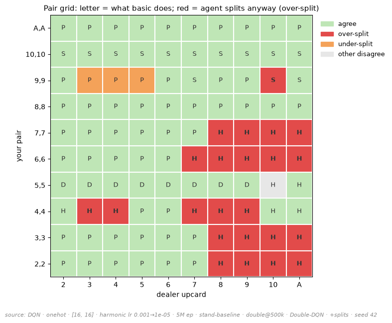

Over-aggression is the dominant error, and it is consistent across seeds and length

| run | genuine | over_split | under_split | over_double | missed_surrender |
| --- | --- | --- | --- | --- | --- |
| [16, 16] splits only, 1.5M, seed 42 | 63 | 22 | 5 | 32 | 0 |
| [16, 16] splits only, 5M, seed 42 | 50 | 24 | 2 | 17 | 0 |
| [16, 16] splits only, 10M, seed 42 | 46 | 22 | 0 | 19 | 0 |
| [16, 16] splits+surrender, 5M, seed 42 | 54 | 23 | 2 | 17 | 3 |
| [64, 64] splits+surrender, 5M, seed 42 | 50 | 24 | 1 | 15 | 3 |
| [16, 16] splits+surrender, 5M, seed 43 | 56 | 21 | 2 | 22 | 3 |

source: genuine-disagreement cells per run; over-split = agent splits where basic does not; missed_surrender = basic surrenders, agent does not. all onehot [16,16] harmonic Double-DQN, seed 42/43

```python
def scat(c):
    a, b = c['agent_action'], c['basic_action']
    if a == b:                        return 0   # correct
    if a == 'split' and b != 'split': return 1   # OVER-split
    if b == 'split' and a != 'split': return 2   # under-split
    return 3                                     # other disagreement
SCOL = ['#bfe6b6', '#e24b4a', '#f4a259', '#e7e7e7']
ACT  = {'hit':'H','stand':'S','double':'D','split':'P','surrender':'R'}
PAIR = {(4,False):'2,2',(6,False):'3,3',(8,False):'4,4',(10,False):'5,5',(12,False):'6,6',
        (14,False):'7,7',(16,False):'8,8',(18,False):'9,9',(20,False):'10,10',(12,True):'A,A'}
ROWS = ['A,A','10,10','9,9','8,8','7,7','6,6','5,5','4,4','3,3','2,2']
COLS = list(range(2,12))

cells = _j.load(open(_P(RUN.path)/'record.json', encoding='utf-8'))['diff']['cells']
pairs = {(PAIR.get((c['player_value'], c['is_soft'])), c['dealer_upcard']): c
         for c in cells if c.get('can_split') and (c['player_value'], c['is_soft']) in PAIR}

fig, ax = plt.subplots(figsize=(7.2, 6.2))
for i, rlab in enumerate(ROWS):
    for j, d in enumerate(COLS):
        c = pairs.get((rlab, d))
        if c is None:
            ax.add_patch(plt.Rectangle((j,i),1,1,facecolor='white',edgecolor='#dddddd')); continue
        cat = scat(c)
        ax.add_patch(plt.Rectangle((j,i),1,1,facecolor=SCOL[cat],edgecolor='white',lw=1.5))
        ax.text(j+0.5, i+0.5, ACT[c['basic_action']], ha='center', va='center',
                fontsize=9, color='#333', fontweight='bold' if cat==1 else 'normal')
ax.set_xlim(0,len(COLS)); ax.set_ylim(0,len(ROWS)); ax.set_aspect('equal'); ax.invert_yaxis()
ax.set_xticks([j+0.5 for j in range(len(COLS))]); ax.set_xticklabels(['A' if d==11 else d for d in COLS])
ax.set_yticks([i+0.5 for i in range(len(ROWS))]); ax.set_yticklabels(ROWS)
ax.set_xlabel('dealer upcard'); ax.set_ylabel('your pair')
ax.set_title('Pair grid: letter = what basic does; red = agent splits anyway (over-split)', fontsize=11)
leg = [mpatches.Patch(color=SCOL[0],label='agree'), mpatches.Patch(color=SCOL[1],label='over-split'),
       mpatches.Patch(color=SCOL[2],label='under-split'), mpatches.Patch(color=SCOL[3],label='other disagree')]
ax.legend(handles=leg, loc='upper left', bbox_to_anchor=(1.01,1), frameon=False, fontsize=9)
fignote('source: ' + describe(RUN))
plt.tight_layout(); plt.show()

def breakdown(row):
    d = [c for c in _j.load(open(_P(row.path)/'record.json',encoding='utf-8'))['diff']['cells']
         if c['category']=='genuine_disagreement']
    osp = sum(1 for c in d if c['agent_action']=='split'  and c['basic_action']!='split')
    usp = sum(1 for c in d if c['basic_action']=='split'  and c['agent_action']!='split')
    odl = sum(1 for c in d if c['agent_action']=='double' and c['basic_action']!='double')
    sur = sum(1 for c in d if c['basic_action']=='surrender')
    cfg = ('splits+surrender' if row.with_surrender else 'splits only')
    return dict(run='%s %s, %gM, seed %s'%(row.hidden,cfg,row.episodes/1e6,row.seed), genuine=len(d),
                over_split=osp, under_split=usp, over_double=odl, missed_surrender=sur)

splits_runs = df[df.with_splits & (df.method=='dqn')].sort_values(['with_surrender','episodes','seed'])
tab2 = pd.DataFrame([breakdown(r) for _,r in splits_runs.iterrows()])
show(tab2, caption='Over-aggression is the dominant error, and it is consistent across seeds and length',
     source='source: genuine-disagreement cells per run; over-split = agent splits where basic does not; '
            'missed_surrender = basic surrenders, agent does not. all onehot [16,16] harmonic Double-DQN, seed 42/43')
```

## 6.3 — The corner it never enters: surrender

Surrender is the opposite kind of action: defensive, and rare. In this rule set basic strategy surrenders in just **three** of the 340 cells — hard 15 vs 10, hard 16 vs 9, and hard 16 vs 10 — the three hands so bad that giving up half your bet beats playing on. The network surrenders in **zero**. It hits all three.

```python
sur = [c for c in cells if c['basic_action']=='surrender']
srow = pd.DataFrame([dict(hand='hard %d'%c['player_value'], dealer=('A' if c['dealer_upcard']==11 else c['dealer_upcard']),
                          basic=c['basic_action'], agent=c['agent_action']) for c in sur])
show(srow, caption='The three surrender cells — basic gives up, the agent hits every one',
     source='source: ' + describe(RUN) + ' · surrender enabled (with_surrender=True)')
```

The three surrender cells — basic gives up, the agent hits every one

| hand | dealer | basic | agent |
| --- | --- | --- | --- |
| hard 15 | 10 | surrender | hit |
| hard 16 | 9 | surrender | hit |
| hard 16 | 10 | surrender | hit |

source: DQN · onehot · [16, 16] · harmonic lr 0.001→1e-05 · 5M ep · stand-baseline · double@500k · Double-DQN · +splits · seed 42 · surrender enabled (with_surrender=True)

**Reading it.** Surrender fails for the same reason over-splitting succeeds-too-often: a smooth function cannot carve out a sharp, low-frequency island. Splitting's correct region has a hard *outer* edge, so the net overshoots it. Surrender's correct region is three isolated cells with a thin EV margin over hitting — so the net, averaging over their common neighbours, never lifts surrender's value above hit's anywhere, and the island simply never forms. One action gets over-used, the other never used; both are the absence of a wall.

The cost is small — three rare cells — so it barely moves the edge, and we don't dress it up as more than it is. But it completes the picture: the smooth approximator's single structural weakness shows up as *over-aggression* on sharp-bounded aggressive actions and as *blindness* to rare defensive ones.

## 6.4 — Training length, and the ceiling it never reaches

Does more training rescue the full game? It helps, on the same terms as Chapter 5: the over-aggression shrinks and the edge falls, but it plateaus short of the exact-table ceiling. On the splits game the edge runs 2.05% → 1.12% → 0.74% across 1.5M, 5M and 10M episodes, and back-half agreement climbs 0.82 → 0.84 → 0.85 — real improvement, never closing on tabular's 0.94.

More training shrinks the over-aggression but plateaus short of the exact-table ceiling

| episodes | back_half_agreement | edge_pct |
| --- | --- | --- |
| 1.5M | 81.9% | 2.05 |
| 5M | 84.0% | 1.12 |
| 10M | 84.7% | 0.74 |

source: splits-only series (surrender off), onehot [16,16] harmonic Double-DQN, seed 42 · back-half mean agreement, edge %/hand vs basic

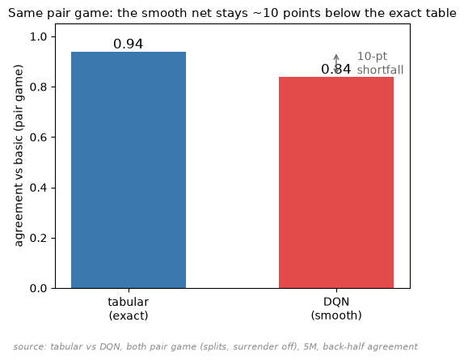

Four times the neurons, same wall: capacity barely moves agreement or the over-splitting

| network | back_half_agreement | edge_pct | over_split |
| --- | --- | --- | --- |
| [16, 16] | 83.0% | 1.03 | 23 |
| [64, 64] | 84.1% | 0.92 | 24 |

source: complete game (splits+surrender), harmonic Double-DQN, 5M, seed 42 — [16,16] vs [64,64]

```python
length = df[df.with_splits & (df.method=='dqn') & ~df.with_surrender].sort_values('episodes')
ltab = pd.DataFrame([dict(episodes='%gM'%(r.episodes/1e6), back_half_agreement=back_half(r), edge_pct=r.edge_pct)
                     for _, r in length.iterrows()])
show(ltab, pct=['back_half_agreement'], num=['edge_pct'],
     caption='More training shrinks the over-aggression but plateaus short of the exact-table ceiling',
     source='source: splits-only series (surrender off), onehot [16,16] harmonic Double-DQN, seed 42 · '
            'back-half mean agreement, edge %/hand vs basic')

# the exact-vs-approximate ceiling on the SAME game (pair game, both methods) — just two bars
DQN_PAIR = df[df.with_splits & ~df.with_surrender & (df.method=='dqn') & (df.episodes==5_000_000)].iloc[0]
tab_ag, dqn_ag = back_half(TAB), back_half(DQN_PAIR)   # both pair game, 5M, surrender off
fig, ax = plt.subplots(figsize=(5.2, 4.2))
bars = ax.bar(['tabular\n(exact)', 'DQN\n(smooth)'], [tab_ag, dqn_ag], width=0.55, color=['#3a78ad', '#e24b4a'])
for b in bars:
    ax.text(b.get_x()+b.get_width()/2, b.get_height()+0.012, '%.2f'%b.get_height(), ha='center', fontsize=12)
ax.annotate('', xy=(1, dqn_ag), xytext=(1, tab_ag), arrowprops=dict(arrowstyle='<->', color='#666'))
ax.text(1.10, (tab_ag+dqn_ag)/2, '%.0f-pt\nshortfall'%((tab_ag-dqn_ag)*100), color='#666', fontsize=10, va='center')
ax.set_ylim(0, 1.05); ax.set_ylabel('agreement vs basic (pair game)')
ax.set_title('Same pair game: the smooth net stays ~%.0f points below the exact table'%((tab_ag-dqn_ag)*100), fontsize=10.5)
fignote('source: tabular vs DQN, both pair game (splits, surrender off), 5M, back-half agreement')
plt.tight_layout(); plt.show()

# does more CAPACITY help the full game? the matched [64,64] complete-game run vs the [16,16] hero
def cap_row(row):
    d = [c for c in _j.load(open(_P(row.path)/'record.json',encoding='utf-8'))['diff']['cells']
         if c['category']=='genuine_disagreement']
    osp = sum(1 for c in d if c['agent_action']=='split' and c['basic_action']!='split')
    return dict(network=row.hidden, back_half_agreement=back_half(row), edge_pct=row.edge_pct, over_split=osp)
cap = df[df.with_splits & df.with_surrender & (df.method=='dqn') & (df.seed==42)].sort_values('hidden')
captab = pd.DataFrame([cap_row(r) for _, r in cap.iterrows()])
show(captab, pct=['back_half_agreement'], num=['edge_pct'],
     caption='Four times the neurons, same wall: capacity barely moves agreement or the over-splitting',
     source='source: complete game (splits+surrender), harmonic Double-DQN, 5M, seed 42 — [16,16] vs [64,64]')
```

That [64,64] run also settles the cross-game question cleanly, with the network held fixed. The same architecture scores 0.911 on the trimmed game and 0.841 on the complete game; against the exact table (0.928 → 0.940) the agreement gap widens from **~2 points to ~10**. Because the net is identical across the two games, that widening is real — not the [16,16]-vs-[64,64] artifact we were careful not to claim earlier. Adding hard-edged actions, not shrinking the network, is what opens the gap. Capacity was never the missing wall; representation is.

## 6.5 — Verdict

The complete game confirms the thesis the whole report has been assembling, and sharpens it. The smooth network's weakness is not about doubling, or about any one action. It is structural: **a single smooth function cannot represent the sharp, low-frequency boundaries that optimal blackjack is made of.** Give it an aggressive action with a hard edge — double, split — and it over-extends past the edge. Give it a rare defensive action — surrender — and it never carves out the island. An exact table, free to memorise each cell, does all of it nearly perfectly.

So the headline holds at full size: this DQN plays a competent, recognisably-good complete game — roughly 1% to the house — but it is competent *despite* a fixed structural ceiling, not on its way to closing it. The ceiling is the price of generalisation, and it is exactly the wall Chapter 4 found, now counted twice over.

And to be clear about what this chapter is and is not: it is a confirmation, not an investigation. We did not tune, sweep, or dissect splitting and surrender the way we dissected doubling — they are here to show the full game behaves as the trimmed game predicted, and no more should be read into the pair-play numbers than that.

# Chapter 7 — What this actually was

We picked a problem with a known answer on purpose. Single-hand blackjack has an *exact* optimum — basic strategy, a lookup table proven optimal — so a learning agent could be measured against truth in every state. Six chapters used that ruler. This one steps back and asks what the whole exercise measured.

The short version was already on the table in Chapter 1, and nothing since has overturned it: **the table wins on exactness, simplicity, and zero tuning; the network is competent, not defeated.** What was *missing* in Chapter 1 was the why. We introduced the decision-tree frame there as a promise — three axes along which a lookup table and a neural network partition the same space differently — and said Chapter 7 would re-derive every finding from those three axes. That promise comes due here.

## 7.1 — The whole journey, one scoreboard

Every milestone, measured the same way — fresh shoe, 200k hands, agent and basic paired on the same seeded shoes, agreement as a back-half mean. The trimmed game (hit/stand/double) and the complete game (+split +surrender) side by side.

```python
import sys; sys.path.insert(0, '.')
import statistics as st
import numpy as np, pandas as pd
from runs import load_runs, learning_curve, cell_categories, agreement_on, show, provenance, describe, OPTIMUM_PCT, EDGE_SE_PCT

df = load_runs(); dqn = df[df.method == 'dqn']
def back_half(path):
    a = [cp['agreement'] for cp in learning_curve(path) if cp.get('agreement') is not None]
    return st.mean(a[len(a)//2:]) if a else float('nan')

# --- trimmed game: the SAME selections Chapter 1 uses, so the synthesis cannot contradict it ---
net_grid = set(cell_categories(dqn[~dqn.with_splits].iloc[0].path))
tab   = df[(df.method=='tabular') & (df.episodes==5_000_000) & (~df.with_splits)]
naive = dqn[(dqn.hidden=='[64, 64]') & (dqn.episodes==1_000_000) & (~dqn.swa) & (dqn.lr_schedule=='constant')
            & (dqn.reward_baseline=='none') & (dqn.double_after==0) & (~dqn.with_splits)]
naive = naive[naive.edge_pct < 4.0]
best  = dqn[(~dqn.with_splits) & dqn.has_model].assign(bh=lambda d:[back_half(p) for p in d.path]).sort_values('bh').iloc[-1]
basic_a = df[(~df.with_splits) & df.basic_edge_pct.notna()].basic_edge_pct.mean()

# --- complete game (Chapter 6 selections) ---
tab_f  = df[df.with_splits & (df.method=='tabular')].sort_values('agreement').iloc[-1]
best_f = df[df.with_splits & (df.method=='dqn')].assign(bh=lambda d:[back_half(p) for p in d.path]).sort_values('bh').iloc[-1]
basic_f = df[df.with_splits & df.basic_edge_pct.notna()].basic_edge_pct.mean()

board = pd.DataFrame([
    {'game':'trimmed', 'method':'basic strategy (no-split optimum)', 'agreement':float('nan'), 'edge_pct':OPTIMUM_PCT['trimmed'], 'tuning':'—'},
    {'game':'trimmed', 'method':'tabular Q-learner',        'agreement':st.mean([agreement_on(p,net_grid) for p in tab.path]), 'edge_pct':tab.edge_pct.mean(), 'tuning':'none'},
    {'game':'trimmed', 'method':'naive DQN',                'agreement':naive.agreement.mean(), 'edge_pct':naive.edge_pct.mean(), 'tuning':'defaults'},
    {'game':'trimmed', 'method':'best DQN',                 'agreement':back_half(best.path), 'edge_pct':best.edge_pct, 'tuning':'full stack'},
    {'game':'+split','method':'basic strategy (full optimum)', 'agreement':float('nan'), 'edge_pct':OPTIMUM_PCT['complete'], 'tuning':'—'},
    {'game':'+split','method':'tabular Q-learner',        'agreement':back_half(tab_f.path) if not np.isnan(back_half(tab_f.path)) else tab_f.agreement, 'edge_pct':tab_f.edge_pct, 'tuning':'none'},
    {'game':'+split','method':'best DQN',                 'agreement':back_half(best_f.path), 'edge_pct':best_f.edge_pct, 'tuning':'full stack'},
])
show(board, pct=['agreement'], num=['edge_pct'],
     caption='The whole journey — agreement = match to the table on each game\'s grid (≈240 cells trimmed, ≈340–367 with splits); edge = %/hand vs basic, lower better. Tabular agreement is its converged value (no per-checkpoint log); DQN agreement is the back-half mean.',
     source='source: trimmed rows use Chapter 1\'s exact run selections; split rows use Chapter 6\'s (best expanded-game DQN is the 10M splits run; surrender is the 3-cell corner of Ch6.3, omitted here as no surrender-enabled tabular run exists). '
            'basic = mean over the no-split / split run pool respectively (fresh-shoe 200k, paired seed). '
            'tabular trimmed scored on the common 240-cell grid.')
```

The whole journey — agreement = match to the table on each game's grid (≈240 cells trimmed, ≈340–367 with splits); edge = %/hand vs basic, lower better. Tabular agreement is its converged value (no per-checkpoint log); DQN agreement is the back-half mean.

| game | method | agreement | edge_pct | tuning |
| --- | --- | --- | --- | --- |
| trimmed | basic strategy (no-split optimum) | nan% | 1.11 | — |
| trimmed | tabular Q-learner | 92.8% | 1.34 | none |
| trimmed | naive DQN | 82.1% | 1.94 | defaults |
| trimmed | best DQN | 91.1% | 0.90 | full stack |
| +split | basic strategy (full optimum) | nan% | 0.54 | — |
| +split | tabular Q-learner | 94.0% | 0.17 | none |
| +split | best DQN | 84.7% | 0.74 | full stack |

source: trimmed rows use Chapter 1's exact run selections; split rows use Chapter 6's (best expanded-game DQN is the 10M splits run; surrender is the 3-cell corner of Ch6.3, omitted here as no surrender-enabled tabular run exists). basic = mean over the no-split / split run pool respectively (fresh-shoe 200k, paired seed). tabular trimmed scored on the common 240-cell grid.

**Reading it.** Two readings, the same as Chapter 1, now carried through to the full game.

On **agreement**, the table leads in both games and the lead *widens* as the game grows: a couple of points in the trimmed game (~0.93 vs ~0.91), about ten with splits added (~0.94 vs ~0.85). On **edge**, the trimmed-game learners are within noise of each other and of the no-split optimum (~1.11%): the gaps are a few tenths against a ±0.26%/hand eval band, so they can't be ranked. On the split game the table is clearly ahead (its ~0.17% vs the net's ~0.7%, a >2-SE gap). More actions, each with its own hard boundary (split here, surrender in Ch6.3),, cost the smooth approximator more; the exact table just stores them.

But hold the frame from Chapter 1: the per-game optima are ~1.11% (no-split) and ~0.54% (full); the trimmed learners land within noise of theirs, while on the full game the smooth net sits a few tenths above its 0.54% optimum. The story is not "the net failed." It is that the gap *has a shape* — and the shape is the same one axis, showing up wherever the game adds a wall.

## 7.2 — The three axes, earned

Chapter 1 said a network and a decision tree differ along three axes, and that every finding would be one of them. With the evidence in, here is the verdict on each.

[output not shown]

So of the three axes, only the **boundary** axis is a genuine, permanent limit. The cut-direction axis was benign; the shared-cells axis caused a transient (fixable) wobble and bought a real advantage. The whole report collapses to one sentence: **a smooth approximator cannot place sharp, low-frequency boundaries — and optimal blackjack is made of them.** Everything else was either fixable (Ch3) or in the net's favour (generalization).

## 7.3 — Why we trust the shape

A finding this clean invites suspicion that it was manufactured. It was not, and Chapter 5 is the reason. Every number here is a *back-half mean*, never a transient peak; every comparison is *paired* (agent and basic on identical shoes) and *matched* (one variable at a time — the trap that nearly turned Chapter 3.3's lr-and-Double-DQN contamination into a false capacity effect); and we trusted only the metrics graded by the ruler — agreement and edge — over the ones the agent computes about itself, which shrink with confidence rather than correctness. The boundary residual survived all of that discipline. That is why it goes in as the conclusion and not a caveat.

## 7.4 — The reframe, and the bottom line

Here is the last turn of the frame Chapter 1 set up. On a problem whose model is *known*, computing the table is simply the right answer — exact, instant, untrainable-away. So the network's gap is not a failure to be closed; it is a **measurement** of something specific: the cost of solving the problem *model-free*, as if you did not know the rules. That cost, read off the scoreboard, is a couple of agreement points and near-zero edge in the trimmed game, widening to ~10 points and a few tenths of a percent once the full action set is on — and in exchange you get a policy that generalises to states no table ever visited. Stated that way, "the table wins" is not a defeat. It is the price tag on generality, and we now know its size and its shape: it is concentrated entirely on the sharp boundaries, and nowhere else.

**What this is honest about.** Several rows lean on single seeds; a matched [64,64] run confirms the trimmed-vs-complete gap widens ~2→10 points with the architecture held fixed (so the widening is real, not a net-size artifact), and that more capacity neither closed it nor reduced the over-splitting; evaluation is fresh-shoe throughout, which flatters basic's edge relative to a penetrated shoe; and splitting and surrender were a confirmation, not a study. None of these touch the central claim — the boundary residual appears in every configuration we ran — but they bound how hard any single number should be pushed.

**What it was, in the end.** A small, exactly-checkable RL problem, used not to build a blackjack bot but to ask *where a function approximator's policy departs from a known optimum, and why* — and to answer it with a single mechanism, three times confirmed, measured under a discipline strict enough to believe. The table wins. The network tells you, precisely, what generality costs.